# Predicting Student Success: A Multi-Model Machine Learning Approach

– Early Warning System for Student Dropout Risk

Dongyuan Gao, Ramiro Díez-Liébana, Cyriel Van Helleputte

2026-01-03

# Summary

**Our Storyline:** Higher education institutions face significant challenges with **student drop-outs**. A fictional university has engaged our education consulting firm to understand what influences student dropout and how to better prevent dropouts. The university wants to **understand and improve academic performance**, and design **interventions** that reduce failed academic lives. Understanding which students are **at risk of dropping out**, and timely support that can change academic and life trajectories.

**Our Data:** We have chosen a real case dataset from **University of California, Irvine (UCI)**, to simulate the fictional case. We found the dataset because the renowned data repository appeared in our Machine Learning 1 lecture.

**Our Approach:** We analyzed **4,424 students** from a Portuguese higher education institution using **six** machine learning models to predict student outcomes (**Dropout**, **Graduate(not dropout)**) and **understand the factors that drive academic success**. **Project Repository:** [Click here to view full code & repository on GitHub](https://github.com/dydy2010/machine_learning_I_Project)

## Key Findings:

- **First & Second semester performance is the strongest predictor** of academic outcomes across all models.
- **2 Early warning systems** could be built upon our models.
- **Non-linear relationships exist** between age, course load, and success.
- **Model accuracy ranges from 70-90%** depending on the prediction task, with graduation prediction(test set) achieving the highest reliability (**AUC ≈ 0.87**)

**Business Impact:** These models enable our client university to **identify at-risk students early**, **allocate resources**, and implement **targeted interventions** that can improve graduation rates.

# 1. Introduction & Data Context

## 1.1 Business Questions & Model Mapping

**Student dropout** is a critical issue in higher education. As noted by the OECD, “In Switzerland, STEM completion rates are 68%, lower than those for health and welfare, at 81%” (OECD, 2025). To address it, we deploy six modeling approaches, each answering a specific business question:

1. **How do 1st-semester results predict students’ final graduation/dropout?** (Binomial GLM / GAM)
   - *Purpose:* Early intervention based on initial performance.
2. **Can we predict 2nd-semester grades?** (Linear Regression / Gaussian GAM)
   - *Purpose:* Forecasting academic performance. The prediction result could be beneficial for intervention methods.
3. **Can we predict how many courses will a student pass in the 1st semester?** (Poisson GLM)
   - *Purpose:* Identifying students struggling with studies. The prediction result could be beneficial for intervention methods.
4. **How do major factors like 2nd semester performance and finance predict students’ final graduation/dropout?** (SVM / Neural Net)
   - *Purpose:* High-accuracy classification for targeted support.

By predicting **dropout risk early**, institutions can intervene with:

- Academic support programs
- Financial aid counseling
- Mental health services
- Personalized study plans

## 1.2 Team Contributions

This project was completed collaboratively by three team members, with each member taking the lead on specific models:

| Team Member | Models Led | Contributions |
| --- | --- | --- |
| **Cyriel** | Linear Regression, GLM (Binomial & Poisson), GAM | Exploratory Analysis |
| **Ramiro** | Support Vector Machines | Data Preprocessing |
| **Dongyuan Gao** | Neural Networks | Cross-validation, All-models improvement & Report Editing |

## 1.3 Data Source and Selection Process

### Choosing Our Dataset

**Our goal** for this project is to deliver a **solid report** while using it as an opportunity to **enhance our understanding** of **machine learning concepts** and practices. With this in mind, we explored several *potential datasets* for our final analysis.

We considered **three main dataset options**. First, the Social Media Fact Sheet from PEW Research Center, which would have allowed us to analyze social media usage patterns. Second, medical quality service data in Switzerland from the Federal Office of Public Health (available through opendata.swiss). Third, student data for predicting dropout and academic success from the UC Irvine Machine Learning Repository.

After careful consideration, we chose the third option from the UC Irvine repository. The **data structure and scope align well with our goal** of getting familiarized with machine learning concepts and practices and producing a solid report as our first attempt in the ML world. Though the other two datasets were interesting to explore, their structure, diversity, and scope did not suit our *learning objectives* as well as the student success dataset. For the exploration experience, we didn’t read any papers related to the dataset online while doing the project.

### Dataset Characteristics

**Source:** UCI Machine Learning Repository - Predict Students’ Dropout and Academic Success  
**Institution:** Portuguese higher education institution  
**Time Period:** Multiple academic years  
**Sample Size:** 4,424 students with 37 variables (e.g., age, 1st-semester grades, credits completed)

The dataset provides a comprehensive view of student characteristics and outcomes. It is well-suited for applying multiple machine learning models.

**Target Variable (3 factors):**

- **Dropout:** Students who left the program (1,421 students, 32%)
- **Enrolled:** Students currently continuing (794 students, 18%), in some models counted as binary ‘not-dropout’.
- **Graduate:** Students who completed successfully (2,209 students, 50%)

The distribution shows a balanced dataset with a slight majority of graduates. It reflects the institution’s overall success rate and provides sufficient samples across all outcome categories for model training.

## 1.4 Feature Categories and detailed variables

Our dataset includes **36 predictors** in the following categories: Demographic Information, Socioeconomic Factors, Academic Background, Academic Performance, Financial Indicators, and Macroeconomic Context. To make the business case and model results easier to follow, the table below summarizes the most important variables used.

Key dataset variables (collapsed view)

| Variable | Meaning | Type |
| --- | --- | --- |
| Target | Student outcome (Dropout / Enrolled / Graduate) | Categorical (3 classes) |
| Admission.grade | Admission exam/entry score used for program entry | Numeric |
| Previous.qualification..grade. | Grade from the previous qualification (prior education) | Numeric |
| Age.at.enrollment | Student age when enrolling in the program | Numeric |
| Gender | Student gender (coded numerically in the dataset) | Categorical (coded) |
| Scholarship.holder | Whether the student holds a scholarship (0/1) | Binary (0/1) |
| Debtor | Whether the student is classified as a debtor (0/1) | Binary (0/1) |
| Tuition.fees.up.to.date | Whether tuition fees are paid up to date (0/1) | Binary (0/1) |
| Curricular.units.1st.sem..enrolled. | Number of courses the student enrolled in (1st semester) | Count |
| Curricular.units.1st.sem..approved. | Number of courses successfully passed (1st semester) | Count |
| Curricular.units.1st.sem..grade. | Average grade in the 1st semester (0–20 scale) | Numeric |

### Why This Dataset Works for Our Analysis

The dataset is suitable for applying all required machine learning methods:

**For Linear Regression:** We have **continuous grade variables (0-20 scale)**, allowing us to predict second semester performance based on first semester results and student characteristics.

**For Binomial GLM:** The three-class target can be converted to **Graduate vs Dropout**, enabling logistic regression with **interpretable odds ratios**.

**For Poisson GLM:** **Count variables** are present (approved courses, evaluations, failed courses), making it ideal for count-based modeling.

**For GAM, Neural Networks, and SVM:** The mix of **continuous and categorical predictors** plus a **classification task** allow us to explore **non-linear relationships** and **interactions**.

The dataset contains **4,424 observations**—large **enough** for robust train-test splits and complex **training**, yet manageable. With **36 predictors** across demographic, academic, financial, and socioeconomic domains, we have the sources to deliver **insights for our client**.

# 2. Exploratory Data Analysis

Before all teammates exploring models, we cast categorical/binary fields to factors and ran one-way ANOVAs of each numeric feature vs the three-level `Target` (see `data/preprocessing`), then saved `data/preprocessed_data.csv`. We also quickly check for missing values below, we found out that there are no missing values (it is not common in real world cases, but it fit our goal of focusing on exploring machine learning concepts and models in this project.)  
Secondly, we did a simple **Anova** important features screening, to have an overview of the importance features for each teammate to work on. Higher F means that feature’s average differs a lot across Dropout/Enrolled/Graduate; in our Anova chart, **semester grades/approvals** differ the most between groups, financial next, and demographics least. So each of our teammates can explore the important features first, and use features that are model specific to their models.

## 2.1 Data Preprocessing

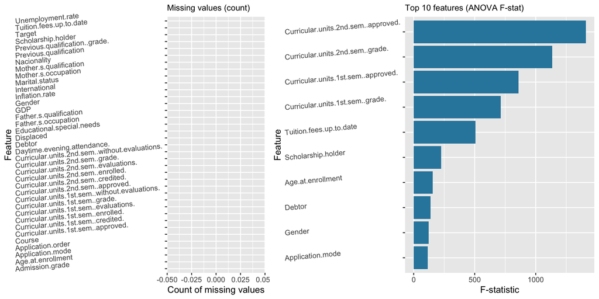

```r
# Simple ANOVA screening: each numeric feature vs Target (see data/preprocessing)
# Missing value counts per column
missing_summary <- df %>%
  summarise(across(everything(), ~ sum(is.na(.)))) %>%
  pivot_longer(cols = everything(),
               names_to = "variable",
               values_to = "n_missing") %>%
  mutate(percentage = round(n_missing / nrow(df) * 100, 2)) %>%
  arrange(desc(n_missing))

p_missing <- ggplot(missing_summary, aes(x = reorder(variable, n_missing), y = n_missing)) +
  geom_col(fill = "#6C8EBF") +
  coord_flip() +
  labs(title = "Missing values (count)",
       x = "Feature",
       y = "Count of missing values") +
  theme(axis.text.y = element_text(angle = 5, hjust = 0),
        plot.title = element_text(size = 10))

# One-way ANOVA per numeric feature vs Target (univariate screening)
numeric_feats <- names(df)[sapply(df, is.numeric)]
anova_results <- lapply(numeric_feats, function(feat) {
  fit <- aov(as.formula(paste(feat, "~ Target")), data = df)
  f_val <- summary(fit)[[1]]$`F value`[1]
  data.frame(Feature = feat, F_value = f_val)
}) %>%
  bind_rows() %>%
  arrange(desc(F_value))

top_anova <- head(anova_results, 10)

ggplot(top_anova, aes(x = reorder(Feature, F_value), y = F_value)) +
  geom_col(fill = "#2E86AB") +
  coord_flip() +
  labs(title = "Top 10 features (ANOVA F-stat)",
       x = "Feature",
       y = "F-statistic") +
  theme(axis.text.y = element_text(angle = 5, hjust = 0),
        plot.title = element_text(size = 10)) -> p_anova

gridExtra::grid.arrange(p_missing, p_anova, ncol = 2, widths = c(0.9, 1.1))
```

## 2.2 Target Variable Distribution & Age Distribution

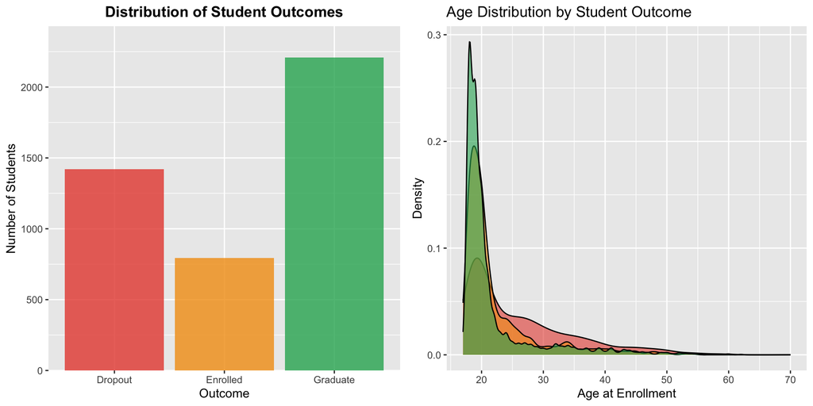

```r
# Create a bar plot with percentages
target_summary <- df %>%
  group_by(Target) %>%
  summarise(count = n()) %>%
  mutate(percentage = count / sum(count) * 100)

p_target <- ggplot(target_summary, aes(x = Target, y = count, fill = Target)) +
  geom_bar(stat = "identity", alpha = 0.8) +
  scale_fill_manual(values = c("Dropout" = "#E74C3C",
                                "Enrolled" = "#F39C12",
                                "Graduate" = "#27AE60")) +
  scale_y_continuous(expand = expansion(mult = c(0, 0.1))) +
  labs(title = "Distribution of Student Outcomes",
       x = "Outcome", y = "Number of Students", fill = "Outcome") +
  theme(legend.position = "none",
        plot.title = element_text(hjust = 0.5, face = "bold"))

p_age <- ggplot(df, aes(x = Age.at.enrollment, fill = Target)) +
  geom_density(alpha = 0.6) +
  scale_fill_manual(values = c("Dropout" = "#E74C3C",
                                "Enrolled" = "#F39C12",
                                "Graduate" = "#27AE60")) +
  labs(title = "Age Distribution by Student Outcome",
       x = "Age at Enrollment", y = "Density", fill = "Outcome") +
  theme(legend.position = "none")

p_target_noleg <- p_target + theme(legend.position = "none")
p_age_noleg <- p_age + theme(legend.position = "none")

gridExtra::grid.arrange(
  gridExtra::arrangeGrob(p_target_noleg, p_age_noleg, ncol = 2, widths = c(1, 1))
)
```

**Key Observation:** The dataset shows a **reasonable distribution** for modeling, with 50% graduates, 32% dropouts, and 18% still enrolled. This balance allows models to learn patterns for all outcomes effectively. Depending on the model and task, we may need to **adjust** the classes to **binary(dropout or not dropout)**.

**Insight:** Age shows interesting patterns: common students age **(18-22)** have **higher graduation rates**, while both younger and significantly older students face elevated dropout risks. This pattern suggests that age effects may not follow a linear trend, which we could explore using models that can capture such **non-linear** relationships (e.g., *GAMs* with smooth terms, or GLMs with *polynomial/spline* features). Though Age is possibly not an important factor (as Anova shows).

## 2.3 Semester Performance-Financial Factor Effect Overview

To have a **first overview** of the **important factors** from Anova test, we show the *second semester performance* plots together with the key *financial factors* in one combined figure below.

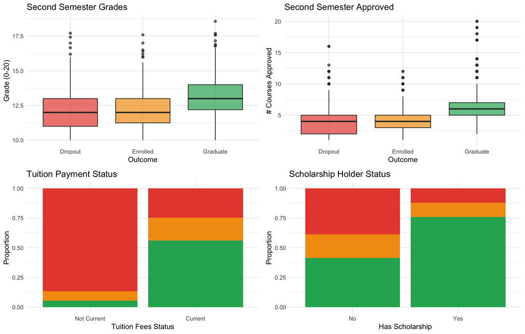

```r
# Prepare data for second semester grades
second_sem_data <- df %>%
  filter(!is.na(Curricular.units.2nd.sem..grade.) &
         Curricular.units.2nd.sem..grade. > 0) %>%
  select(Target, Curricular.units.2nd.sem..grade.,
         Curricular.units.2nd.sem..approved.)

# Prepare financial data
financial_data <- df %>%
  select(Target, Tuition.fees.up.to.date, Scholarship.holder, Debtor) %>%
  mutate(Tuition.fees.up.to.date = factor(Tuition.fees.up.to.date,
                                          levels = c(0, 1),
                                          labels = c("Not Current", "Current")),
         Scholarship.holder = factor(Scholarship.holder,
                                     levels = c(0, 1),
                                     labels = c("No", "Yes")),
         Debtor = factor(Debtor,
                         levels = c(0, 1),
                         labels = c("No", "Yes")))

outcome_colors <- c("Dropout" = "#E74C3C",
                    "Enrolled" = "#F39C12",
                    "Graduate" = "#27AE60")

# Box plot for second semester grades
p_grade <- ggplot(second_sem_data,
                  aes(x = Target, y = Curricular.units.2nd.sem..grade., fill = Target)) +
  geom_boxplot(alpha = 0.7) +
  scale_fill_manual(values = outcome_colors) +
  labs(title = "Second Semester Grades",
       x = "Outcome", y = "Grade (0-20)", fill = "Outcome") +
  theme_minimal(base_size = 11)

# Box plot for courses approved
p_approved <- ggplot(second_sem_data,
                     aes(x = Target, y = Curricular.units.2nd.sem..approved., fill = Target)) +
  geom_boxplot(alpha = 0.7) +
  scale_fill_manual(values = outcome_colors) +
  labs(title = "Second Semester Approved",
       x = "Outcome", y = "# Courses Approved", fill = "Outcome") +
  theme_minimal(base_size = 11)

# Tuition status
p_tuition <- ggplot(financial_data, aes(x = Tuition.fees.up.to.date, fill = Target)) +
  geom_bar(position = "fill") +
  scale_fill_manual(values = outcome_colors) +
  labs(title = "Tuition Payment Status",
       x = "Tuition Fees Status", y = "Proportion", fill = "Outcome") +
  theme_minimal(base_size = 11)

# Scholarship status
p_scholarship <- ggplot(financial_data, aes(x = Scholarship.holder, fill = Target)) +
  geom_bar(position = "fill") +
  scale_fill_manual(values = outcome_colors) +
  labs(title = "Scholarship Holder Status",
       x = "Has Scholarship", y = "Proportion", fill = "Outcome") +
  theme_minimal(base_size = 11)

p_grade_noleg <- p_grade + theme(legend.position = "none")
p_approved_noleg <- p_approved + theme(legend.position = "none")
p_tuition_noleg <- p_tuition + theme(legend.position = "none")
p_scholarship_noleg <- p_scholarship + theme(legend.position = "none")

gridExtra::grid.arrange(
  p_grade_noleg, p_approved_noleg,
  p_tuition_noleg, p_scholarship_noleg,
  ncol = 2,
  widths = c(1, 1)
)
```

**Insight (financial factors):** Students who **pay tuition on time** and who **hold scholarships** show much higher graduation rates and lower dropout proportions. Financial stability appears to be a strong protective factor.

# 3. Modeling Approach & Strategy

## 3.1 Model Characteristics

We employ six modeling techniques, each with distinct strengths:

| Model | Purpose | Strengths |
| --- | --- | --- |
| **Linear Regression** | Predict continuous grades | Interpretable, fast, baseline for comparison |
| **GLM (Binomial)** | Binary classification | Probabilistic output, interpretable odds ratios |
| **GLM (Poisson)** | Count data prediction | Appropriate for non-negative integer outcomes |
| **GAM** | Non-linear relationships | Captures curves, visualizable, flexible |
| **Neural Networks** | Complex patterns | Learns interactions automatically, high capacity |
| **SVM** | Robust classification | Maximum margin, kernel tricks, outlier resistant |

## 3.2 Research Questions

Each model could address specific questions we have in mind:

1. **Linear Regression:** How do student characteristics linearly predict **second semester grades**?
2. **GLM (Binomial):** How factors distinguish **graduates from dropouts** in probabilistic terms?
3. **GLM (Poisson):** How it predicts the **count of approved courses** in each semester?
4. **GAM:** Can GAM with **non-linear relationships** better predict dropout?
5. **Neural Networks:** Can **neural deep learning** better **predict dropout**?
6. **SVM:** Can we build a **robust classifier** that maximizes the margin between success and failure?

## 3.3 Evaluation Strategy

- **Training/Test Split:** **80/20 stratified split** to maintain class balance
- **Regression Metrics:** **R²**, **RMSE**, **MAE**
- **Classification Metrics:** **Accuracy**, **AUC-ROC**, **Confusion Matrix**
- **Cross Validation:** Compare models

# 4. Linear Regression Analysis

## 4.2 Methodology

Linear regression models a continuous outcome (here: **2nd semester grade**) as a weighted sum of input features:

$$Y = \beta_0 + \beta_1X_1 + \beta_2X_2 +
... + \beta_nX_n + \epsilon$$

Here, $Y$ is the 2nd semester grade, $X_i$ are the input variables, and $\beta_i$ are the estimated coefficients. Each $\beta_i$ tells us how $Y$ is expected to change when $X_i$ increases by 1 unit (while keeping other variables constant). The term $\epsilon$ represents unexplained variation.

We predict **2nd semester grades** using **13 features**, including demographics, earlier academic information, and macroeconomic indicators. This matches the idea that student outcomes depend on multiple factors, not just one.

## 4.3 Data Preparation

```r
TARGET <- 'Curricular.units.2nd.sem..grade.'

FEATURES <- c(
    'Previous.qualification..grade.',
    'Admission.grade',
    'Age.at.enrollment',
    "Mother.s.qualification",
    "Father.s.qualification",
    'Scholarship.holder',
    'Curricular.units.1st.sem..credited.',
    'Curricular.units.1st.sem..enrolled.',
    'Curricular.units.1st.sem..approved.',
    'Curricular.units.1st.sem..grade.',
    'Unemployment.rate',
    'Inflation.rate',
    'GDP'
)

df_model <- df %>%
    select(all_of(c(FEATURES, TARGET))) %>%
    mutate(across(everything(), ~ as.numeric(as.character(.)))) %>%
    drop_na() %>%
    filter(get(TARGET) > 0)
```

After preparing the dataset (we did not observe missing values in EDA, but we keep `drop_na()` as a safety check) and excluding zero grades, the linear regression model uses **3554 students**. The target variable (**2nd semester grade**) has **mean** **12.73** and **standard deviation** **1.38**.

The dataset is filtered to **exclude students with zero grades**, as these typically represent withdrawals or incomplete coursework rather than actual performance. This ensures our model focuses on **predicting outcomes for actively enrolled students**.

## 4.4 Linear EDA

```r
correlations <- cor(df_model[FEATURES], df_model[[TARGET]])
correlations_sorted <- sort(correlations[,1], decreasing = TRUE)

top5_cor <- data.frame(
  Feature = names(head(correlations_sorted, 5)),
  Correlation = as.numeric(round(head(correlations_sorted, 5), 3))
)

knitr::kable(top5_cor, caption = "Top 5 correlations with 2nd semester grade")
```

Top 5 correlations with 2nd semester grade

| Feature | Correlation |
| --- | --- |
| Curricular.units.1st.sem..grade. | 0.516 |
| Admission.grade | 0.276 |
| Curricular.units.1st.sem..approved. | 0.250 |
| Previous.qualification..grade. | 0.249 |
| Scholarship.holder | 0.102 |

### Feature Relationships

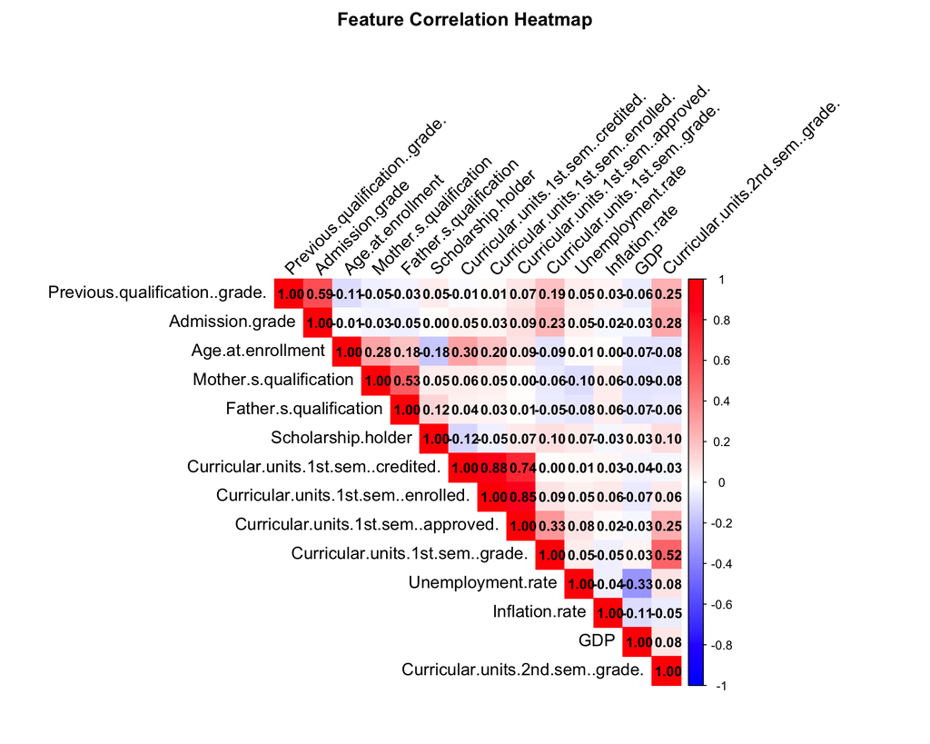

```r
correlation_matrix <- cor(df_model[c(FEATURES, TARGET)])

corrplot(correlation_matrix,
         method = "color",
         type = "upper",
         tl.col = "black",
         tl.srt = 45,
         tl.cex = 1.1,        # Increased from 0.7 for bigger text
         col = colorRampPalette(c("blue", "white", "red"))(200),
         addCoef.col = "black",
         number.cex = 0.9,    # Increased from 0.4 for readable numbers
         title = "Feature Correlation Heatmap",
         mar = c(0, 0, 2, 0))
```

**Key Observations:** Strong positive correlations are evident between **first semester performance metrics** and **second semester grades**, suggesting that prior academic success is highly predictive. This finding supports the importance of **early intervention programs** targeting first-semester students.

## 4.5 Model Development

```r
set.seed(42)

trainIndex <- createDataPartition(df_model[[TARGET]], p = 0.8, list = FALSE)

train_data <- df_model[trainIndex, ]
test_data <- df_model[-trainIndex, ]
y_train <- train_data[[TARGET]]
y_test <- test_data[[TARGET]]

train_n <- nrow(train_data)
test_n <- nrow(test_data)
```

We use an **80/20 train-test split**, resulting in **2844** training observations and **710** test observations, even for the linear model.

**Fitted equation (with coefficients):**

```
Predicted Curricular.units.2nd.sem..grade. = 5.349 + 0.008 *
Previous.qualification..grade. + 0.013 * Admission.grade + 0.007 * Age.at.enrollment +
-0.002 * Mother.s.qualification + 0 * Father.s.qualification + 0.033 * Scholarship.holder
+ -0.144 * Curricular.units.1st.sem..credited. + 0.024 *
Curricular.units.1st.sem..enrolled. + 0.151 * Curricular.units.1st.sem..approved. + 0.266
* Curricular.units.1st.sem..grade. + 0.028 * Unemployment.rate + -0.025 * Inflation.rate
+ 0.06 * GDP
```

Drop-one (partial) F-tests: top predictors

| Feature | Df | F value | Pr(>F) |
| --- | --- | --- | --- |
| Curricular.units.1st.sem..grade. | 1 | 406.895267 | 0.00e+00 |
| Curricular.units.1st.sem..approved. | 1 | 64.095027 | 0.00e+00 |
| Curricular.units.1st.sem..credited. | 1 | 60.071568 | 0.00e+00 |
| Admission.grade | 1 | 44.154399 | 0.00e+00 |
| GDP | 1 | 34.488722 | 0.00e+00 |
| Previous.qualification..grade. | 1 | 15.578555 | 8.11e-05 |
| Unemployment.rate | 1 | 10.508061 | 1.20e-03 |
| Age.at.enrollment | 1 | 4.055237 | 4.41e-02 |

**Interpretation:** `drop1(model, test = "F")` checks each feature one by one. It asks: *if we remove this feature from the linear model, does the model get noticeably worse?* If yes, the feature is considered more useful.

**What we see in our results table:**

- **Curricular.units.1st.sem..grade.** is by far the strongest predictor (very large F). Its coefficient ≈ 0.27 means: **each 1-point increase in 1st semester grade predicts a 0.27-point change in 2nd semester grade**.
- **Curricular.units.1st.sem..approved.** (coef ≈ 0.15) and **Curricular.units.1st.sem..credited.** are also strong. For example, for each course approved(passed), the predicted 2nd semester grade increases by 0.15 points.
- **Admission.grade** (coef ≈ 0.013) shows meaningful contribution—higher admission grades predict slightly better 2nd semester performance.
- **Age.at.enrollment** is weaker (smaller F and borderline p-value).

## 4.7 Visual Assessment & Performance Interpretation

**Performance Interpretation:** The R² score of 0.372 indicates that 37.2% of variance in second semester grades can be explained by our selected features. **The Mean Absolute Error (MAE)** of 0.86 means our predictions are typically within 0.86 grade points of actual values.  
It provides a **solid baseline**, but there is room for more flexible models.

**How to read the 4-panel plot:** In the two scatter plots, points closer to the red dashed line mean better predictions; here we see a clear trend but with spread (so it’s not perfect). The two residual plots show errors are mostly centered around 0 with a few outliers, which is acceptable for a simple baseline model.

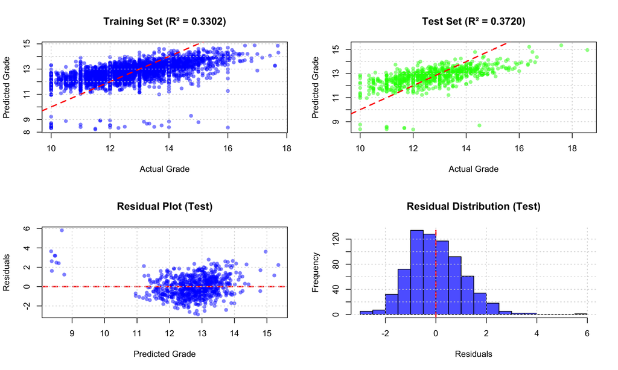

Actual vs. Predicted Grades

```r
par(mfrow = c(2, 2))

plot(y_train, y_train_pred,
     xlab = "Actual Grade", ylab = "Predicted Grade",
     main = sprintf("Training Set (R² = %.4f)", train_r2),
     pch = 16, col = rgb(0, 0, 1, 0.5))
abline(a = 0, b = 1, col = "red", lwd = 2, lty = 2)
grid()

plot(y_test, y_test_pred,
     xlab = "Actual Grade", ylab = "Predicted Grade",
     main = sprintf("Test Set (R² = %.4f)", test_r2),
     pch = 16, col = rgb(0, 1, 0, 0.5))
abline(a = 0, b = 1, col = "red", lwd = 2, lty = 2)
grid()

residuals_test <- y_test - y_test_pred

plot(y_test_pred, residuals_test,
     xlab = "Predicted Grade", ylab = "Residuals",
     main = "Residual Plot (Test)",
     pch = 16, col = rgb(0, 0, 1, 0.5))
abline(h = 0, col = "red", lwd = 2, lty = 2)
grid()

hist(residuals_test, breaks = 30,
     xlab = "Residuals", ylab = "Frequency",
     main = "Residual Distribution (Test)",
     col = rgb(0, 0, 1, 0.7), border = "black")
abline(v = 0, col = "red", lwd = 2, lty = 2)
grid()
```

**Final takeaway (linear regression):** Using the selected features, the linear regression model can produce a **reasonable prediction** of **2nd semester grades**. With a test R² of about **0.37** and MAE around **0.86**, it works well as a **simple and interpretable baseline**. We could later use this prediction tool to predict dropout on top. In the next section we move to a **Binomial GLM (logistic regression)** for dropout prediction.

# 5. Generalized Linear Model - Binomial

## 5.1 Introduction to Classification

**Business Question:** *“Can we predict which student is more at risk of dropping out?”*

This is until now our **most actionable model**—by estimating the **odds of dropout**, we can identify at-risk students and enable targeted interventions.

**Response Variable:** `Dropout` =1, `NotDropout`=0. - **Dropout:** Students who dropped out - **NotDropout:** Students who are still enrolled OR graduated (both are “surviving”)

**Methodology:**Classification problems require predicting categorical outcomes rather than continuous values. Binomial logistic regression excels at binary classification by estimating probabilities between 0 and 1 through the logistic (sigmoid) function:

$$P(Y=1) = \frac{1}{1 + e^{-(\beta_0 +
\beta_1X_1 + ... + \beta_nX_n)}}$$

This S-shaped curve ensures predictions stay within valid probability bounds. It allows us to model how predictor variables influence the **odds of dropping out**.

## 5.2 Quick & Dirty EDA: Key Predictors

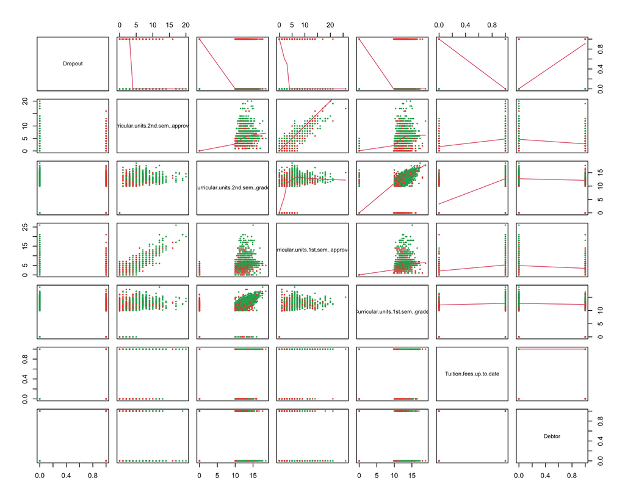

```r
# Prepare data for pairs plot - using top 6 from ANOVA F-stat
df_pairs <- df %>%
  mutate(Dropout = ifelse(Target == 'Dropout', 1, 0)) %>%
  select(Dropout,
         Curricular.units.2nd.sem..approved.,
         Curricular.units.2nd.sem..grade.,
         Curricular.units.1st.sem..approved.,
         Curricular.units.1st.sem..grade.,
         Tuition.fees.up.to.date,
         Debtor) %>%
  na.omit()

# Pairs plot with smooth lines
pairs(Dropout ~ Curricular.units.2nd.sem..approved. +
               Curricular.units.2nd.sem..grade. +
               Curricular.units.1st.sem..approved. +
               Curricular.units.1st.sem..grade. +
               Tuition.fees.up.to.date +
               Debtor,
      data = df_pairs,
      upper.panel = panel.smooth,
      col = ifelse(df_pairs$Dropout == 1, "#E74C3C", "#27AE60"),
      pch = 16, cex = 0.5)
```

**Key Interpretations:** Most of these factors(pre-filtered by ANOVA) **show linear correlation** with dropout, except **tuition and debtor** are **slightly weaker**. For **example**, 2nd sem approved - Very clear negative linear trend: more courses approved means lower dropout. The patterns seem to be quite suitable for GLM models.

## 5.3 Full Model: Data Preparation and Training

```r
# --- Data prep: Dropout=1, NotDropout=0 (consistent with NN/SVM)
df_dropout <- df %>%
  mutate(Dropout = ifelse(Target == 'Dropout', 1, 0))

# Include 2nd semester variables for comparison with other models
features_dropout <- c(
  'Previous.qualification..grade.',
  'Admission.grade',
  'Age.at.enrollment',
  'Mother.s.qualification',
  'Father.s.qualification',
  'Scholarship.holder',
  'Gender',
  'Debtor',
  'Tuition.fees.up.to.date',
  'Curricular.units.1st.sem..approved.',
  'Curricular.units.1st.sem..grade.',
  'Curricular.units.2nd.sem..approved.',
  'Curricular.units.2nd.sem..grade.',
  'Unemployment.rate',
  'Inflation.rate',
  'GDP'
)

df_dropout_model <- df_dropout %>%
  select(all_of(c(features_dropout, 'Dropout'))) %>%
  mutate(across(everything(), as.numeric)) %>%
  na.omit()

# --- Train/test split + scaling
set.seed(42)
train_index <- createDataPartition(df_dropout_model$Dropout, p = 0.8, list = FALSE)
train_data <- df_dropout_model[train_index, ]
test_data <- df_dropout_model[-train_index, ]

preproc <- preProcess(train_data[, features_dropout], method = c("center", "scale"))
train_scaled <- predict(preproc, train_data)
test_scaled <- predict(preproc, test_data)

# --- Fit full model (16 predictors)
glm_full <- glm(Dropout ~ .,
                data = train_scaled,
                family = binomial(link = "logit"))
```

### Model Summary

```
##
## Call:
## glm(formula = Dropout ~ ., family = binomial(link = "logit"),
##     data = train_scaled)
##
## Coefficients:
##                                     Estimate Std. Error z value Pr(>|z|)
## (Intercept)                         -1.14372    0.05765 -19.838  < 2e-16 ***
## Previous.qualification..grade.      -0.03547    0.06174  -0.574  0.56568
## Admission.grade                     -0.11821    0.06048  -1.955  0.05063 .
## Age.at.enrollment                    0.35540    0.05199   6.836 8.15e-12 ***
## Mother.s.qualification               0.08674    0.06400   1.355  0.17530
## Father.s.qualification              -0.03437    0.06152  -0.559  0.57643
## Scholarship.holder                  -0.42641    0.06341  -6.725 1.76e-11 ***
## Gender                               0.12185    0.05052   2.412  0.01587 *
## Debtor                               0.14891    0.05302   2.808  0.00498 **
## Tuition.fees.up.to.date             -0.74824    0.06068 -12.331  < 2e-16 ***
## Curricular.units.1st.sem..approved.  0.17829    0.12654   1.409  0.15885
## Curricular.units.1st.sem..grade.     0.17835    0.09937   1.795  0.07268 .
## Curricular.units.2nd.sem..approved. -1.31592    0.13761  -9.563  < 2e-16 ***
## Curricular.units.2nd.sem..grade.    -0.59307    0.10777  -5.503 3.74e-08 ***
## Unemployment.rate                    0.11060    0.05377   2.057  0.03970 *
## Inflation.rate                       0.04359    0.05110   0.853  0.39364
## GDP                                 -0.04769    0.05539  -0.861  0.38919
## ---
## Signif. codes:  0 '***' 0.001 '**' 0.01 '*' 0.05 '.' 0.1 ' ' 1
##
## (Dispersion parameter for binomial family taken to be 1)
##
##     Null deviance: 4414.1  on 3539  degrees of freedom
## Residual deviance: 2526.5  on 3523  degrees of freedom
## AIC: 2560.5
##
## Number of Fisher Scoring iterations: 5
```

### Coefficient Interpretation with ilogit() from the above Model Summary Output

We interpret the significant coefficients (p < 0.001) using `ilogit()` to convert log-odds to probabilities:

```r
# Helper function: inverse logit
ilogit <- function(x) exp(x) / (1 + exp(x))

# Calculate key values for inline display
or_tuition <- exp(coef(glm_full)["Tuition.fees.up.to.date"])
or_2nd_approved <- exp(coef(glm_full)["Curricular.units.2nd.sem..approved."])
or_2nd_grade <- exp(coef(glm_full)["Curricular.units.2nd.sem..grade."])
or_age <- exp(coef(glm_full)["Age.at.enrollment"])

baseline_prob <- ilogit(coef(glm_full)["(Intercept)"]) * 100
tuition_prob <- ilogit(coef(glm_full)["(Intercept)"] + coef(glm_full)["Tuition.fees.up.to.date"]) * 100
```

**Key Interpretation:** The strongest predictors from the full model are:

- **2nd semester approved** (OR = 0.27, meaning 73% lower dropout odds per SD)
- **2nd semester grade** (OR = 0.55, 45% lower odds per SD)
- **Tuition payment** (OR = 0.47, 53% lower odds if current)
- **Age at enrollment** (OR = 1.43, 43% higher odds per SD for older students)

For example, the baseline dropout probability is 24.2%, but drops to 13.1% for students with tuition paid (+1 SD).

## 5.5 Model Refinement Process

```r
# Reduced model using 2nd semester data (4 significant predictors)
final_model <- glm(Dropout ~ Tuition.fees.up.to.date +
                             Curricular.units.2nd.sem..approved. +
                             Curricular.units.2nd.sem..grade. +
                             Age.at.enrollment,
                   data = train_scaled,
                   family = binomial(link = "logit"))

# Early Warning model: 1st semester only (for early intervention)
glm_early <- glm(Dropout ~ Tuition.fees.up.to.date +
                           Curricular.units.1st.sem..approved. +
                           Curricular.units.1st.sem..grade. +
                           Age.at.enrollment,
                 data = train_scaled,
                 family = binomial(link = "logit"))
```

Based on the summary p-values, we create additionally a **Reduced Model** with 4 predictors (2nd semester performance, Tuition, Age) for our final dropout classifier. This uses the **strongest predictors** while remaining interpretable. We also make another **Early Warning Model** with 4 predictors (1st semester performance, Tuition, Age), so that the customer could predict using first sem data for possible **early action**. These models will be **compared** in the next part.

## 5.6 Model Evaluation (Reduced Model)

We evaluate the **Reduced Model** on the test set:

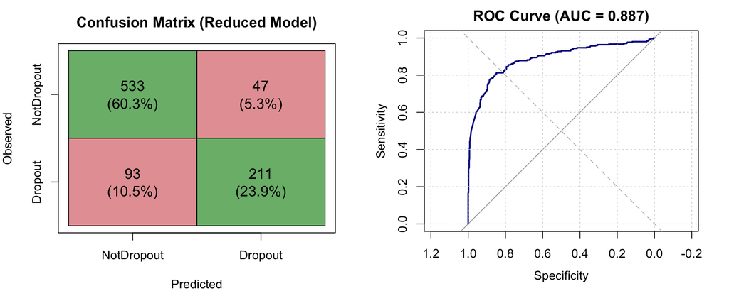

Final Binomial GLM: Confusion Matrix and ROC Curve

```r
# --- Predictions using final model (reduced)
pred_prob <- predict(final_model, test_scaled, type = "response")
pred_class <- ifelse(pred_prob > 0.5, 1, 0)

# --- Metrics
roc_obj <- roc(test_scaled$Dropout, pred_prob, quiet = TRUE)
auc_val <- auc(roc_obj)
accuracy_val <- mean(pred_class == test_scaled$Dropout)

# --- Combined plot: Confusion Matrix + ROC
par(mfrow = c(1, 2), mar = c(4, 4, 3, 2))

# Confusion Matrix as heatmap
conf_matrix <- table(Observed = test_scaled$Dropout, Predicted = pred_class)
conf_pct <- round(prop.table(conf_matrix) * 100, 1)

# Create confusion matrix heatmap manually
plot(c(0, 2), c(0, 2), type = "n", xlab = "Predicted", ylab = "Observed",
     xaxt = "n", yaxt = "n", main = "Confusion Matrix (Reduced Model)")
axis(1, at = c(0.5, 1.5), labels = c("NotDropout", "Dropout"))
axis(2, at = c(0.5, 1.5), labels = c("Dropout", "NotDropout"))

# TN (top-left), FP (top-right), FN (bottom-left), TP (bottom-right)
rect(0, 1, 1, 2, col = rgb(0.2, 0.6, 0.2, 0.7))  # TN - green
rect(1, 1, 2, 2, col = rgb(0.8, 0.2, 0.2, 0.5))  # FP - red
rect(0, 0, 1, 1, col = rgb(0.8, 0.2, 0.2, 0.5))  # FN - red
rect(1, 0, 2, 1, col = rgb(0.2, 0.6, 0.2, 0.7))  # TP - green

text(0.5, 1.5, paste0(conf_matrix[1,1], "\n(", conf_pct[1,1], "%)"), cex = 1.2)
text(1.5, 1.5, paste0(conf_matrix[1,2], "\n(", conf_pct[1,2], "%)"), cex = 1.2)
text(0.5, 0.5, paste0(conf_matrix[2,1], "\n(", conf_pct[2,1], "%)"), cex = 1.2)
text(1.5, 0.5, paste0(conf_matrix[2,2], "\n(", conf_pct[2,2], "%)"), cex = 1.2)

# ROC Curve
plot(roc_obj, col = "darkblue", lwd = 2,
     main = sprintf("ROC Curve (AUC = %.3f)", auc_val))
abline(a = 0, b = 1, lty = 2, col = "gray")
grid()
```

**Performance Summary:** - **Accuracy:** 84.2% - **AUC:** 0.887 It seems quite good for prediction purpose.

### ANOVA: Comparing 3 Models

Now we compare the 3 models using Anova(1st sem focused(early warning), 2nd sem focused(reduced to essential predictors), full model)

|  | Resid. Df | Resid. Dev | Df | Deviance | Pr(>Chi) |
| --- | --- | --- | --- | --- | --- |
| Early Warning (1st sem) | 3535 | 2893.936 | NA | NA | NA |
| Reduced (2nd sem) | 3535 | 2619.298 | 0 | 274.63796 | NA |
| Full (16 vars) | 3523 | 2526.487 | 12 | 92.81117 | 1.406984e-14 |

**ANOVA Interpretation:** - **Early to Reduced:** as above output shows 274.6 deviance reduction (9.5% improvement) by switching to 2nd semester data - **Reduced to Full:** 92.8 deviance reduction (3.5% improvement) by adding 12 more variables

The **Reduced Model** is the efficient choice—most of the predictive power with only 4 interpretable features. **However**, for the **business case**, predicting only with 2nd semester data might be **too late for action**. So we could choose the **Early Warning Model** (1st semester focused) as our final Binomial GLM. This will be elaborated more in conclusion chapter.

## 5.7 Chapter Conclusion

**Key Observations:** - **2nd semester course performance** (approved + grade) are the dominant predictors - **Tuition payment status** is the strongest financial indicator - Older students at enrollment have slightly higher dropout risk

# 6. Generalized Linear Model - Poisson

## 6.1 Why Poisson Regression?

We use Poisson regression for **1st Semester course completion** prediction because: we know that 1st semester performance(including the **passed courses**) is correlated with the dropout outcome, especially for **early dropout prevention** it could be **very useful**. We **couldn’t** predict this using **linear models** because, course completion counts represent non-negative integers (0, 1, 2, 3…) that don’t follow a normal distribution. Poisson regression solves this by:

1. **Ensuring non-negative predictions** through a log link function
2. **Modeling the count distribution** appropriately
3. **Accounting for variance** that changes with the mean

The model structure is: $\log(\lambda) = \beta_0 + \beta_1X_1 + ... + \beta_nX_n$, where $\lambda$ represents the expected count.

## 6.2 Predicting First Semester Course Approvals (Poisson GLM Model)

**Business case:** Early identification of students likely to pass fewer courses in 1st semester enables timely support interventions. We use only **pre-enrollment data** (admission grades, background, financial status) plus **enrolled courses count** as predictors—data available before semester 1 ends.

We’ll evaluate using: **RMSE** (average prediction error in courses), **MAE** (mean absolute deviation), and **R²** (proportion of variance explained). We’ll also interpret which factors most strongly affect 1st semester success via the **Rate Ratio** (how much the expected count changes per unit increase).

### Data Preparation & Poisson Model Training

We used similar approach as in previous section. We select the features to train on and split the data into training and testing sets(for later evaluation)

```r
TARGET_1 <- 'Curricular.units.1st.sem..approved.'

FEATURES_1 <- c(
    'Previous.qualification..grade.',
    'Admission.grade',
    'Age.at.enrollment',
    "Mother.s.qualification",
    "Father.s.qualification",
    'Scholarship.holder',
    'Gender',
    'Debtor',
    'Tuition.fees.up.to.date',
    'Curricular.units.1st.sem..enrolled.',
    'Unemployment.rate',
    'GDP'
)

df_model1 <- df %>%
    select(all_of(c(FEATURES_1, TARGET_1))) %>%
    mutate(across(everything(), ~ as.numeric(as.character(.)))) %>%
    drop_na()

set.seed(42)
X1 <- df_model1 %>% dplyr::select(all_of(FEATURES_1))
y1 <- df_model1[[TARGET_1]]

train_idx1 <- createDataPartition(y1, p = 0.8, list = FALSE)
X_train1 <- X1[train_idx1, ]
X_test1  <- X1[-train_idx1, ]
y_train1 <- y1[train_idx1]
y_test1  <- y1[-train_idx1]

train_data1 <- X_train1
train_data1[[TARGET_1]] <- y_train1

poisson_model1 <- glm(
  formula = as.formula(paste(TARGET_1, "~ .")),
  family = poisson(link = "log"),
  data = train_data1
)

# --- Performance metrics (for inline display)
y_pred_train1 <- predict(poisson_model1, newdata = X_train1, type = "response")
y_pred_test1 <- predict(poisson_model1, newdata = X_test1, type = "response")

train_rmse1 <- sqrt(mean((y_train1 - y_pred_train1)^2))
test_rmse1 <- sqrt(mean((y_test1 - y_pred_test1)^2))
test_mae1 <- mean(abs(y_test1 - y_pred_test1))
test_r2_1 <- cor(y_test1, y_pred_test1)^2

# --- Rate ratios for top predictors
coef_summary1 <- summary(poisson_model1)$coefficients
coef_df1 <- data.frame(
    Feature = rownames(coef_summary1),
    Coefficient = coef_summary1[, "Estimate"],
    Rate_Ratio = exp(coef_summary1[, "Estimate"]),
    P_value = coef_summary1[, "Pr(>|z|)"]
) %>%
    mutate(Abs_Coef = abs(Coefficient)) %>%
    arrange(desc(Abs_Coef))
```

### Model Summary

```
##
## Call:
## glm(formula = as.formula(paste(TARGET_1, "~ .")), family = poisson(link = "log"),
##     data = train_data1)
##
## Coefficients:
##                                       Estimate Std. Error z value Pr(>|z|)
## (Intercept)                          0.0511920  0.1015382   0.504 0.614146
## Previous.qualification..grade.      -0.0002165  0.0007427  -0.292 0.770625
## Admission.grade                      0.0023269  0.0006813   3.415 0.000638 ***
## Age.at.enrollment                   -0.0097035  0.0011991  -8.092 5.86e-16 ***
## Mother.s.qualification              -0.0002440  0.0006059  -0.403 0.687141
## Father.s.qualification              -0.0002371  0.0005996  -0.395 0.692566
## Scholarship.holder                   0.1647192  0.0181223   9.089  < 2e-16 ***
## Gender                              -0.1400292  0.0173586  -8.067 7.21e-16 ***
## Debtor                              -0.0494198  0.0285052  -1.734 0.082970 .
## Tuition.fees.up.to.date              0.4198881  0.0331454  12.668  < 2e-16 ***
## Curricular.units.1st.sem..enrolled.  0.1445737  0.0022723  63.625  < 2e-16 ***
## Unemployment.rate                    0.0087778  0.0032172   2.728 0.006365 **
## GDP                                  0.0205268  0.0037129   5.528 3.23e-08 ***
## ---
## Signif. codes:  0 '***' 0.001 '**' 0.01 '*' 0.05 '.' 0.1 ' ' 1
##
## (Dispersion parameter for poisson family taken to be 1)
##
##     Null deviance: 8975.5  on 3540  degrees of freedom
## Residual deviance: 5021.3  on 3528  degrees of freedom
## AIC: 15431
##
## Number of Fisher Scoring iterations: 5
```

```r
# Quasi-Poisson to handle overdispersion
quasi_model <- glm(
  formula = as.formula(paste(TARGET_1, "~ .")),
  family = quasipoisson(link = "log"),
  data = train_data1
)

# Use quasi model for predictions (same coefficients, corrected SEs)
y_pred_train1 <- predict(quasi_model, newdata = X_train1, type = "response")
y_pred_test1 <- predict(quasi_model, newdata = X_test1, type = "response")

# Recalculate metrics with quasi model
train_rmse1 <- sqrt(mean((y_train1 - y_pred_train1)^2))
test_rmse1 <- sqrt(mean((y_test1 - y_pred_test1)^2))
test_mae1 <- mean(abs(y_test1 - y_pred_test1))
test_r2_1 <- cor(y_test1, y_pred_test1)^2

# Update rate ratios
coef_summary1 <- summary(quasi_model)$coefficients
coef_df1 <- data.frame(
    Feature = rownames(coef_summary1),
    Coefficient = coef_summary1[, "Estimate"],
    Rate_Ratio = exp(coef_summary1[, "Estimate"]),
    P_value = coef_summary1[, "Pr(>|t|)"]
) %>%
    mutate(Abs_Coef = abs(Coefficient)) %>%
    arrange(desc(Abs_Coef))

dispersion <- summary(quasi_model)$dispersion
```

```
##
## Call:
## glm(formula = as.formula(paste(TARGET_1, "~ .")), family = quasipoisson(link = "log"),
##     data = train_data1)
##
## Coefficients:
##                                       Estimate Std. Error t value Pr(>|t|)
## (Intercept)                          0.0511920  0.0995858   0.514 0.607250
## Previous.qualification..grade.      -0.0002165  0.0007284  -0.297 0.766276
## Admission.grade                      0.0023269  0.0006682   3.482 0.000504 ***
## Age.at.enrollment                   -0.0097035  0.0011761  -8.251  < 2e-16 ***
## Mother.s.qualification              -0.0002440  0.0005942  -0.411 0.681366
## Father.s.qualification              -0.0002371  0.0005881  -0.403 0.686879
## Scholarship.holder                   0.1647192  0.0177739   9.267  < 2e-16 ***
## Gender                              -0.1400292  0.0170248  -8.225 2.71e-16 ***
## Debtor                              -0.0494198  0.0279571  -1.768 0.077198 .
## Tuition.fees.up.to.date              0.4198881  0.0325081  12.916  < 2e-16 ***
## Curricular.units.1st.sem..enrolled.  0.1445737  0.0022286  64.873  < 2e-16 ***
## Unemployment.rate                    0.0087778  0.0031553   2.782 0.005433 **
## GDP                                  0.0205268  0.0036415   5.637 1.87e-08 ***
## ---
## Signif. codes:  0 '***' 0.001 '**' 0.01 '*' 0.05 '.' 0.1 ' ' 1
##
## (Dispersion parameter for quasipoisson family taken to be 0.9619138)
##
##     Null deviance: 8975.5  on 3540  degrees of freedom
## Residual deviance: 5021.3  on 3528  degrees of freedom
## AIC: NA
##
## Number of Fisher Scoring iterations: 5
```

The quasi-Poisson dispersion parameter is 0.96. With corrected standard errors: - **Highly significant** (p < 0.001): Tuition fees, Scholarship, Enrolled courses, Gender, Age, Admission grade, GDP - **Marginally significant** (p < 0.1): Debtor - **Not significant** (p > 0.1): Previous qualification, Mother/Father qualification

### Feature Effects on Course Approvals

We plot the top 10 features with the largest coefficients(exponentialized), and analyze their effects on course approvals(1st sem passed courses).

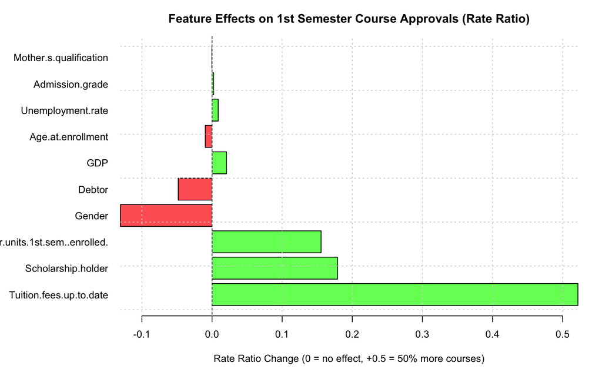

```r
# Rate Ratio bar plot (more intuitive than log coefficients)
coef_plot_df <- coef_df1 %>%
    filter(Feature != "(Intercept)") %>%
    head(10)

par(mar = c(5, 10, 3, 2), cex = 0.8)
colors <- ifelse(coef_plot_df$Rate_Ratio > 1, "green", "red")
barplot(coef_plot_df$Rate_Ratio - 1,
        names.arg = coef_plot_df$Feature,
        horiz = TRUE,
        las = 1,
        col = adjustcolor(colors, alpha.f = 0.7),
        xlab = "Rate Ratio Change (0 = no effect, +0.5 = 50% more courses)",
        main = "Feature Effects on 1st Semester Course Approvals (Rate Ratio)")
abline(v = 0, col = "black", lwd = 1)
grid()
```

**Key Findings — Interpreting Rate Ratios:**

For Poisson models, the Rate Ratio shows how the expected count **multiplies** per unit increase. A Rate Ratio of 1.52 means 52% more courses; 0.87 means 13% fewer.

- **Tuition.fees.up.to.date** (RR = 1.52): Students with tuition paid are expected to pass 52% more courses
- **Scholarship.holder** (RR = 1.18): Scholarship holders pass 18% more courses on average
- **Curricular.units.1st.sem..enrolled.** (RR = 1.16): Each additional enrolled course 16% more approvals

**Negative effects:** Debtor status slightly decrease expected approvals, suggesting this demographic may need extra academic support.

**Actionable insight for advisors:** Financial stability (tuition payment, scholarship) is the strongest predictor of 1st semester success. Early financial interventions could improve outcomes.

## 6.3 Model Evaluation

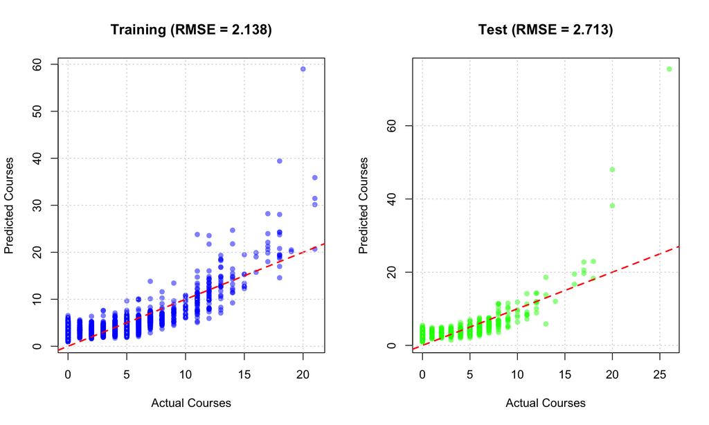

RMSE: Predicted vs Actual Course Approvals

**Performance Summary:**  
- **Test RMSE:** 2.71 courses (average prediction error)  
- **Test MAE:** 1.58 courses  
- **Test R²:** 0.501 (variance explained)

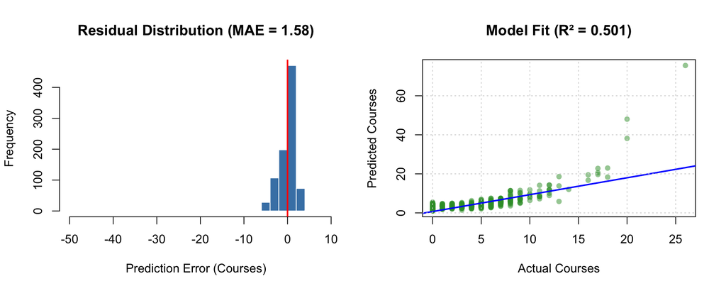

Additional Metrics: MAE and R² Visualization

## 6.4 Chapter Conclusion

This **Poisson GLM** predicts **1st semester course** approvals using pre-enrollment data. The key predictors are enrollment-related factors. While the model has **moderate** predictive power (R² = 0.5), it provides useful **insights** for identifying students who may **struggle in their first semester**.

# 7. Generalized Additive Model - GAM

## 7.1 Introduction: Two GAM Models

All our previous models assumed **linear relationships**. But reality is rarely this simple.

**GAMs** extend **GLMs** by replacing straight lines with **smooth curves**, allowing the model to discover **non-linear patterns** while maintaining interpretability. The model structure: $Y = \beta_0 + f_1(X_1) + f_2(X_2) + ... + f_n(X_n) + \epsilon$, where $f_i$ are smooth, flexible functions learned from data.

**In this section, we build two GAM models:**

1. **Model 1 - Gaussian GAM (Section 7.2)**: Predicts **2nd semester grades** (continuous outcome), similar to the Linear Model in Section 4, but with curves instead of straight lines. Like the linear model, this is not a direct prediction of our business question, but as a step stone, it could help later for more complex prediction systems (multi-step prediction).
2. **Model 2 - Logistic GAM (Section 7.3)**: Predicts **Graduation vs Dropout** (binary outcome), similar to the Binomial GLM in Section 5, but allowing for non-linear risk patterns.

**Our approach:** First, we visually check if non-linearity exists. Then we fit the model, interpret which smooths are significant, and compare performance with simpler linear models.

## 7.2 Model 1: Gaussian GAM for 2nd-Semester Grade Prediction

### Exploratory Analysis: Is Non-Linearity Present?

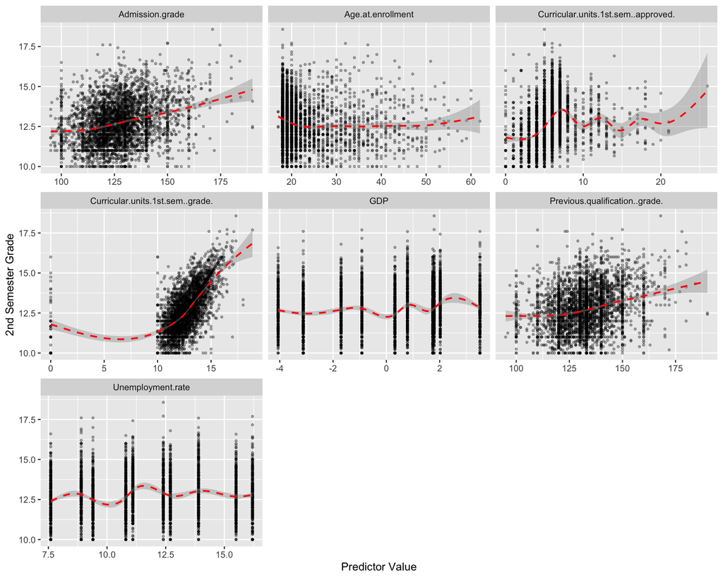

Visual inspection: Do predictors have non-linear relationships?

```r
# Reshape data to long format for faceting (exclude Scholarship.holder - it's categorical)
continuous_predictors <- features_grade[features_grade != 'Scholarship.holder']

df_long <- df_grade %>%
  select(all_of(c(continuous_predictors, TARGET_GRADE))) %>%
  pivot_longer(cols = all_of(continuous_predictors),
               names_to = "Predictor",
               values_to = "Value")

# Single ggplot with facet_wrap
ggplot(df_long, aes(x = Value, y = .data[[TARGET_GRADE]])) +
  geom_point(alpha = 0.3, size = 0.8) +
  geom_smooth(color = "red", linetype = "dashed", linewidth = 0.8) +
  facet_wrap(~ Predictor, scales = "free_x", ncol = 3) +
  labs(x = "Predictor Value", y = "2nd Semester Grade")
```

**Decision:** Non-linearity is clearly present for **semester performance variables**. We’ll fit a GAM with smooths on all continuous predictors, then use **effective degrees of freedom (edf) and p-value** to determine which smooths are truly needed.

### Fitting the GAM for 2nd Semester Grade Prediction

Now that we’ve confirmed non-linearity exists, we fit a GAM model. We’ll start by smoothing all continuous predictors, then examine which smooths are actually needed.

```r
TARGET_GRADE <- 'Curricular.units.2nd.sem..grade.'

features_grade <- c(
  'Previous.qualification..grade.',
  'Admission.grade',
  'Age.at.enrollment',
  'Scholarship.holder',
  'Curricular.units.1st.sem..approved.',
  'Curricular.units.1st.sem..grade.',
  'Unemployment.rate',
  'GDP'
)

df_grade <- df %>%
  select(all_of(c(features_grade, TARGET_GRADE))) %>%
  mutate(across(everything(), as.numeric)) %>%
  na.omit() %>%
  filter(!!sym(TARGET_GRADE) > 0)

cat(sprintf("GAM (grade) dataset: %d students\n", nrow(df_grade)))

set.seed(42)
train_index_g <- createDataPartition(df_grade[[TARGET_GRADE]], p = 0.8, list = FALSE)
train_g <- df_grade[train_index_g, ]
test_g <- df_grade[-train_index_g, ]

gam_grade <- gam(
  Curricular.units.2nd.sem..grade. ~
    s(Previous.qualification..grade., bs = "cr", k = 10) +
    s(Admission.grade, bs = "cr", k = 10) +
    s(Age.at.enrollment, bs = "cr", k = 8) +
    factor(Scholarship.holder) +
    s(Curricular.units.1st.sem..approved., bs = "cr", k = 8) +
    s(Curricular.units.1st.sem..grade., bs = "cr", k = 10) +
    s(Unemployment.rate, bs = "cr", k = 8) +
    s(GDP, bs = "cr", k = 8),
  data = train_g,
  method = "REML"
)

cat("GAM summary:\n")
print(summary(gam_grade))

pred_test_g <- predict(gam_grade, test_g)

test_r2_g <- cor(test_g[[TARGET_GRADE]], pred_test_g)^2
test_rmse_g <- sqrt(mean((test_g[[TARGET_GRADE]] - pred_test_g)^2))
test_mae_g <- mean(abs(test_g[[TARGET_GRADE]] - pred_test_g))

cat(sprintf("GAM performance: R²=%.4f RMSE=%.4f MAE=%.4f\n",
            test_r2_g, test_rmse_g, test_mae_g))
```

### Interpreting the GAM Summary

The GAM summary provides two critical pieces of information for each smooth term:

1. **Effective Degrees of Freedom (edf)**: How “wiggly” the smooth is
   - **edf ≈ 1**: The relationship is essentially **linear** (smooth isn’t needed)
   - **edf ≈ 2-3**: Moderately non-linear
   - **edf > 3**: Highly non-linear, complex curve
2. **p-value**: Is this term statistically significant?
   - **p < 0.05**: Significant predictor
   - **p > 0.05**: Not significant (could be removed)

GAM Smooth Terms: Significance and Non-linearity

|  | Term | EDF | p-value | Significance | Interpretation |
| --- | --- | --- | --- | --- | --- |
| s(Previous.qualification..grade.) | s(Previous.qualification..grade.) | 3.00 | 0.0556 |  | Moderately non-linear |
| s(Admission.grade) | s(Admission.grade) | 1.01 | 0.0068 | ** | Nearly linear |
| s(Age.at.enrollment) | s(Age.at.enrollment) | 2.22 | 0.3686 |  | Moderately non-linear |
| s(Curricular.units.1st.sem..approved.) | s(Curricular.units.1st.sem..approved.) | 5.36 | 0.0000 | *** | Highly non-linear |
| s(Curricular.units.1st.sem..grade.) | s(Curricular.units.1st.sem..grade.) | 5.47 | 0.0000 | *** | Highly non-linear |
| s(Unemployment.rate) | s(Unemployment.rate) | 1.00 | 0.0445 | * | Nearly linear |
| s(GDP) | s(GDP) | 2.71 | 0.0000 | *** | Moderately non-linear |

**Key Findings from GAM Summary:**

- **Highly significant & non-linear** (edf > 3, p < 0.001):
  - `s(Curricular.units.1st.sem..approved.)` - edf ≈ 5.4
  - `s(Curricular.units.1st.sem..grade.)` - edf ≈ 5.5

  These **justify using GAM** - they show complex curved relationships that linear models can’t capture.
- **Nearly linear** (edf ≈ 1):
  - `s(Admission.grade)` - edf ≈ 1.0
  - `s(Unemployment.rate)` - edf ≈ 1.0

  These smooths are **essentially straight lines** - they could be replaced with regular linear terms to save complexity.
- **Not significant** (p > 0.05):
  - `s(Age.at.enrollment)` - p ≈ 0.37

  Age doesn’t significantly improve grade prediction in this model, despite our EDA suggesting some pattern.

### Visualizing the Key Non-Linear Effects

Based on our summary interpretation, we plot only the **significant AND truly non-linear smooths** (edf > 2, p < 0.05).

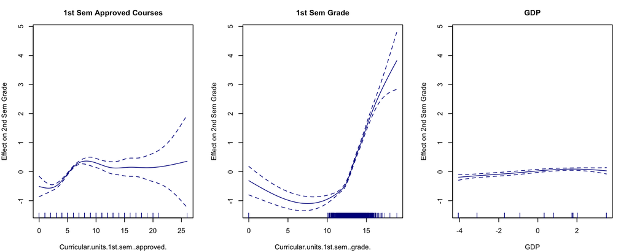

Smooth terms showing true non-linear patterns

```r
par(mfrow = c(1, 3), mar = c(4, 4, 3, 2))

# Plot only the 3 most meaningful smooths
plot(gam_grade, select = 4, shade = TRUE, col = "darkblue", shade.col = "lightblue",
     main = "1st Sem Approved Courses", cex.main = 1.1, ylab = "Effect on 2nd Sem Grade")

plot(gam_grade, select = 5, shade = TRUE, col = "darkblue", shade.col = "lightblue",
     main = "1st Sem Grade", cex.main = 1.1, ylab = "Effect on 2nd Sem Grade")

plot(gam_grade, select = 7, shade = TRUE, col = "darkblue", shade.col = "lightblue",
     main = "GDP", cex.main = 1.1, ylab = "Effect on 2nd Sem Grade")
```

**Interpretation:**

- **1st Sem Approved**: Non-linear pattern—students who pass very few OR complete all courses show different effects than mid-range students.
- **1st Sem Grade**: Strong curve at lower grades—struggling students follow a different trajectory than average performers.
- **GDP**: Moderate curve showing economic factors have some non-linear influence.

### Model Evaluation & Summary

```r
lm_model <- lm(Curricular.units.2nd.sem..grade. ~ ., data = train_g)
lm_pred <- predict(lm_model, test_g)
lm_r2 <- cor(test_g[[TARGET_GRADE]], lm_pred)^2
lm_rmse <- sqrt(mean((test_g[[TARGET_GRADE]] - lm_pred)^2))
lm_mae <- mean(abs(test_g[[TARGET_GRADE]] - lm_pred))
```

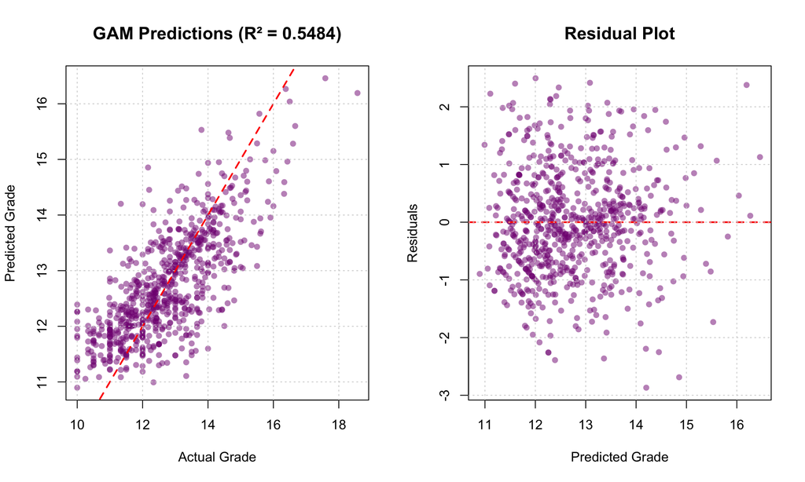

GAM prediction accuracy on test set

GAM vs Linear Model Performance

| Model | R² | RMSE | MAE |
| --- | --- | --- | --- |
| Linear Model (Section 4) | 0.3549 | 1.0943 | 0.8697 |
| GAM | 0.5484 | 0.9166 | 0.7194 |

```r
par(mfrow = c(1, 2))

plot(test_g[[TARGET_GRADE]], pred_test_g,
     pch = 16, col = rgb(0.5, 0, 0.5, 0.5),
     xlab = "Actual Grade", ylab = "Predicted Grade",
     main = sprintf("GAM Predictions (R² = %.4f)", test_r2_g),
     cex.main = 1.3)
abline(0, 1, col = "red", lwd = 2, lty = 2)
grid()

residuals_g <- test_g[[TARGET_GRADE]] - pred_test_g
plot(pred_test_g, residuals_g,
     pch = 16, col = rgb(0.5, 0, 0.5, 0.5),
     xlab = "Predicted Grade", ylab = "Residuals",
     main = "Residual Plot",
     cex.main = 1.3)
abline(h = 0, col = "red", lwd = 2, lty = 2)
grid()
```

**Summary of Gaussian GAM (Model 1):**

- GAM achieves **R² = 0.548** versus **0.355** for Linear Model—an improvement of **19.3 percentage points**.
- The improvement comes from capturing **curved relationships** in 1st semester performance variables.
- Residuals are centered around zero with no systematic bias, indicating a well-fitted model.
- Some variance remains unexplained (~45%), likely due to unmeasured factors like study habits or motivation.

## 7.3 Model 2: Logistic GAM for Graduation Prediction

In Section 5, we used **Binomial GLM** to predict graduation vs dropout, assuming linear relationships. Now we ask: **do non-linear patterns exist for graduation probability?**

We apply the same approach as Model 1: fit a GAM, check which smooths are significant (via edf and p-value), and compare performance with the linear GLM.

### Data Preparation & Model Fitting

```r
df_success <- df %>%
  filter(Target %in% c('Graduate', 'Dropout')) %>%
  mutate(Success = ifelse(Target == 'Graduate', 1, 0))

features_success <- c(
  'Admission.grade',
  'Age.at.enrollment',
  'Scholarship.holder',
  'Tuition.fees.up.to.date',
  'Curricular.units.1st.sem..approved.',
  'Curricular.units.1st.sem..grade.',
  'Curricular.units.2nd.sem..approved.',
  'Curricular.units.2nd.sem..grade.',
  'Unemployment.rate',
  'GDP'
)

df_success_model <- df_success %>%
  dplyr::select(all_of(c(features_success, 'Success'))) %>%
  mutate(across(everything(), as.numeric)) %>%
  na.omit()

set.seed(42)
train_index_s <- createDataPartition(df_success_model$Success, p = 0.8, list = FALSE)
train_s <- df_success_model[train_index_s, ]
test_s <- df_success_model[-train_index_s, ]

gam_success <- gam(
  Success ~
    s(Admission.grade, bs = "cr", k = 10) +
    s(Age.at.enrollment, bs = "cr", k = 8) +
    factor(Scholarship.holder) +
    factor(Tuition.fees.up.to.date) +
    s(Curricular.units.1st.sem..approved., bs = "cr", k = 8) +
    s(Curricular.units.1st.sem..grade., bs = "cr", k = 10) +
    s(Curricular.units.2nd.sem..approved., bs = "cr", k = 8) +
    s(Curricular.units.2nd.sem..grade., bs = "cr", k = 10) +
    s(Unemployment.rate, bs = "cr", k = 8) +
    s(GDP, bs = "cr", k = 8),
  data = train_s,
  family = binomial(link = "logit"),
  method = "REML"
)
```

### Interpreting the Summary

Logistic GAM: Smooth Terms Summary

|  | Term | EDF | p-value | Significant |
| --- | --- | --- | --- | --- |
| s(Admission.grade) | s(Admission.grade) | 4.70 | 0.0002 | Yes |
| s(Age.at.enrollment) | s(Age.at.enrollment) | 4.41 | 0.0000 | Yes |
| s(Curricular.units.1st.sem..approved.) | s(Curricular.units.1st.sem..approved.) | 3.85 | 0.0018 | Yes |
| s(Curricular.units.1st.sem..grade.) | s(Curricular.units.1st.sem..grade.) | 2.34 | 0.0009 | Yes |
| s(Curricular.units.2nd.sem..approved.) | s(Curricular.units.2nd.sem..approved.) | 4.90 | 0.0000 | Yes |
| s(Curricular.units.2nd.sem..grade.) | s(Curricular.units.2nd.sem..grade.) | 3.74 | 0.0002 | Yes |
| s(Unemployment.rate) | s(Unemployment.rate) | 1.00 | 0.0191 | Yes |
| s(GDP) | s(GDP) | 1.73 | 0.3131 | No |

**Interpreting the results:**

**Highly significant & non-linear** (edf > 2, p < 0.05): - `2nd Sem Approved` (edf=4.90, p≈0) - strongest predictor - `Age` (edf=4.41, p≈0) - curved relationship - `Admission Grade` (edf=4.70, p=0.0002) - `2nd Sem Grade` (edf=3.74, p=0.0002) - `1st Sem Approved` (edf=3.85, p=0.002)

**Nearly linear** (edf ≈ 1): - `Unemployment` (edf=1.00, p=0.02) - significant but perfectly linear - `1st Sem Grade` (edf=2.34) - moderately curved

**Not significant**: - `GDP` (p=0.31) - could be dropped from model

### Model Evaluation

```r
pred_proba_s <- predict(gam_success, test_s, type = "response")
pred_s <- ifelse(pred_proba_s > 0.5, 1, 0)

accuracy_s <- mean(pred_s == test_s$Success)
roc_s <- roc(test_s$Success, pred_proba_s, quiet = TRUE)
auc_s <- auc(roc_s)

cat(sprintf("Accuracy: %.4f (%.2f%%)\n", accuracy_s, accuracy_s * 100))
cat(sprintf("AUC-ROC: %.4f\n", auc_s))
```

```r
log_reg <- glm(Success ~ ., data = train_s, family = binomial)
log_pred_proba <- predict(log_reg, test_s, type = "response")
log_roc <- roc(test_s$Success, log_pred_proba, quiet = TRUE)
log_auc <- auc(log_roc)
```

**Performance Comparison:**

| Model | AUC |
| --- | --- |
| Binomial GLM (Section 5) | 0.919 |
| Logistic GAM | 0.932 |

GAM achieves **AUC = 0.932** versus **0.919** for GLM—an improvement of **1.3 percentage points**.

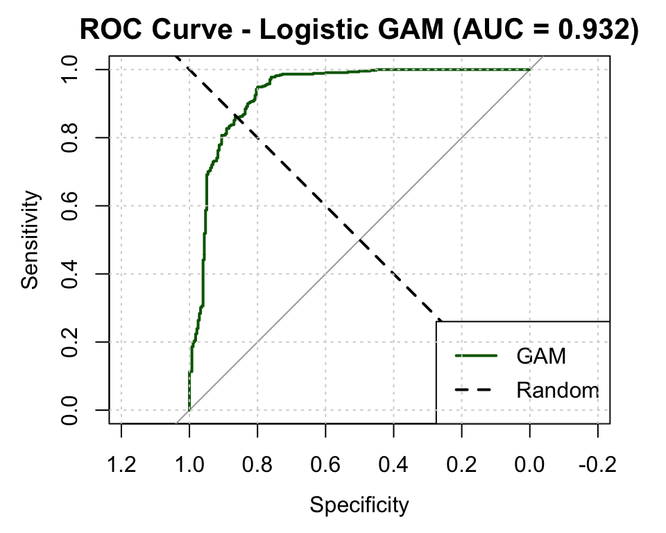

Logistic GAM ROC curve

```r
plot(roc_s, col = "darkgreen", lwd = 2,
     main = sprintf("ROC Curve - Logistic GAM (AUC = %.3f)", auc_s),
     cex.main = 1.3)
abline(a = 0, b = 1, lty = 2, lwd = 2, col = "black")
legend("bottomright", legend = c("GAM", "Random"),
       col = c("darkgreen", "black"), lwd = 2, lty = c(1, 2))
grid()
```

### Visualizing Key Non-Linear Effects

We plot variables with **edf > 2 and p < 0.05** (meaningful non-linearity):

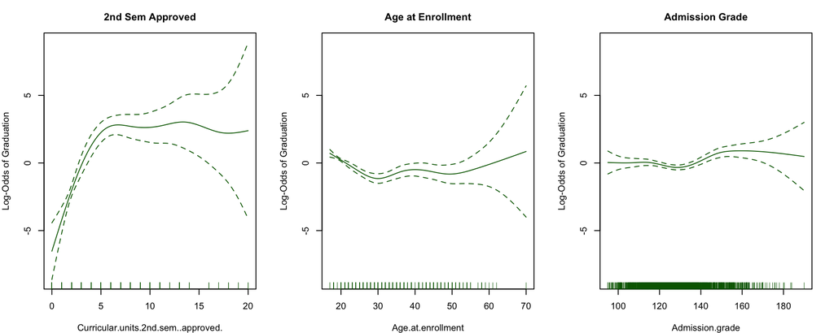

Non-linear graduation probability patterns

```r
par(mfrow = c(1, 3), mar = c(4, 4, 3, 2))

# Plot the 3 most non-linear and significant smooths
plot(gam_success, select = 5, shade = TRUE, col = "darkgreen", shade.col = "lightgreen",
     main = "2nd Sem Approved", cex.main = 1.1, ylab = "Log-Odds of Graduation")

plot(gam_success, select = 2, shade = TRUE, col = "darkgreen", shade.col = "lightgreen",
     main = "Age at Enrollment", cex.main = 1.1, ylab = "Log-Odds of Graduation")

plot(gam_success, select = 1, shade = TRUE, col = "darkgreen", shade.col = "lightgreen",
     main = "Admission Grade", cex.main = 1.1, ylab = "Log-Odds of Graduation")
```

**Interpretation:** - **2nd Sem Approved/Grade**: Strongest predictors, confirming that later academic data provides the clearest signal - **Age**: Young students (18-22) may have different patterns than older students - **Note for Early Warning:** While 2nd semester data maximizes accuracy, a 1st-semester-only model (see GLM in Section 5) enables earlier intervention

### Summary

**Summary of Logistic GAM (Model 2):**

- Logistic GAM achieves **AUC = 0.932**, using both 1st and 2nd semester data
- **2nd semester performance** (edf=4.90) emerges as the dominant non-linear predictor
- **Age** (edf=4.41) shows strong curved relationship - younger students have different graduation patterns
- **GDP** was not significant (p=0.31) and could be dropped in a refined model

# 8. Neural Network Analysis

We use neural networks as an **early warning system** to predict whether a student is at risk of **dropping out** (**Dropout vs NotDropout**) based on early academic performance and financial indicators. Here, **NotDropout** means the student is either **still enrolled** or has **graduated**. The goal is not only accuracy, but also **actionability**: the model should highlight which signals (grades, approved courses, tuition status) are most associated with dropout risk.

## 8.1 Objective

We want our neural network to play the role of an early-warning system: predict **Dropout vs NotDropout** by learning the messy, non-linear patterns hidden in the data.

## 8.2 Feature Selection

We focus on three feature blocks from the preprocessed dataset:

1. **Early academic performance:** 1st- and 2nd-semester grades plus approved credits showed the highest F-values in our ANOVA screening during preprocessing, making them the strongest predictors of the target variable.
2. **Financial pressure/support:** Tuition fees up to date, debtor status, and scholarship holder indicate whether financial stress may affect the student.
3. **Entry profile:** Admission grade and age at enrollment provide baseline information about the student’s starting point.

## 8.3 Data Preprocessing for Neural Networks

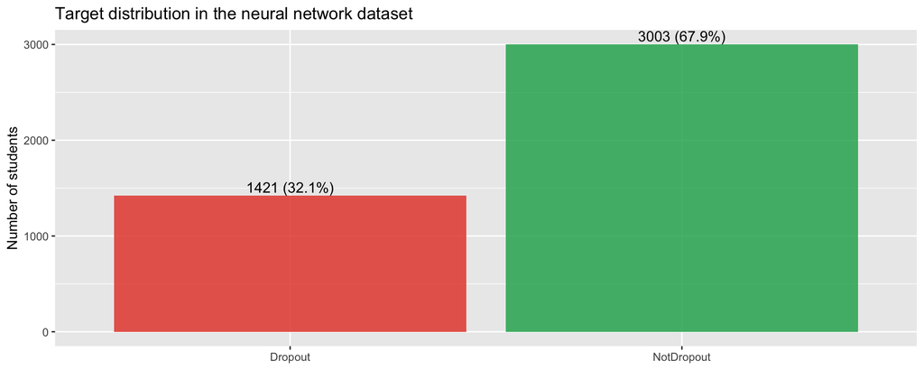

```r
target_counts <- nn_model_data %>%
  count(Target) %>%
  mutate(Percent = n / sum(n) * 100)

ggplot(target_counts, aes(x = Target, y = n, fill = Target)) +
  geom_col(alpha = 0.85) +
  geom_text(aes(label = paste0(n, " (", round(Percent, 1), "%)")), vjust = -0.3, size = 4) +
  scale_fill_manual(values = c("Dropout" = "#E74C3C", "NotDropout" = "#27AE60")) +
  labs(
    title = "Target distribution in the neural network dataset",
    x = NULL,
    y = "Number of students"
  ) +
  theme(legend.position = "none")
```

This modeling subset contains **4424** students after removing missing values. The chart above shows the class balance.

## 8.4 Train/Test Split

```r
set.seed(123)
train_idx <- createDataPartition(nn_model_data$Target, p = 0.8, list = FALSE)
train_nn <- nn_model_data[train_idx, ]
test_nn <- nn_model_data[-train_idx, ]
```

We use an **80/20 split**: training = **3540**, test = **884**.

## 8.5 Model Training

We train two neural networks to compare Lab 1 and Lab 2 approaches.

### Model A: Single Hidden Layer (Lab 1 - nnet)

Following `ANN_Lab1_GermanCredit_v1.Rmd`, we use `nnet` with one hidden layer and weight decay.

```r
# Model A: nnet with single hidden layer (Lab 1 style)
model_A <- nnet(
  Target ~ .,
  data = train_nn,
  size = 10,        # 10 hidden neurons in one layer
  decay = 0.01,     # Weight decay: small penalty on large weights to prevent overfitting
  maxit = 500,      # Maximum training iterations
  trace = FALSE     # Suppress training progress output
)
```

### Model B: Three Hidden Layers (Lab 2 - neuralnet)

Following `ANN_Lab2_Iris_v1.Rmd`, we use `neuralnet` with a deeper architecture using **three hidden layers**. This requires numeric inputs and numeric output columns, so we build 0/1 columns for our binary target.

In this run, Model B uses a **2-5-2** hidden-layer setup (2 neurons - 5 neurons - 2 neurons). We also set `threshold = 0.8` mainly to keep runtime manageable while we debug and iterate. A **larger** threshold usually stops earlier (faster), but it can also stop before the model has learned enough.

```r
# One-hot encode predictors for neuralnet (Lab 2 approach)
dummies <- dummyVars(Target ~ ., data = train_nn)
train_matrix <- as.data.frame(predict(dummies, newdata = train_nn))
test_matrix <- as.data.frame(predict(dummies, newdata = test_nn))

# Create dummy columns for binary target (neuralnet needs numeric output)
train_matrix$Target_Dropout <- as.numeric(train_nn$Target == "Dropout")
train_matrix$Target_NotDropout <- as.numeric(train_nn$Target == "NotDropout")

# Build formula: output columns ~ input columns
input_names <- names(train_matrix)[!grepl("Target", names(train_matrix))]
output_names <- c("Target_Dropout", "Target_NotDropout")
formula_B <- as.formula(paste(
  paste(output_names, collapse = " + "), "~",
  paste(input_names, collapse = " + ")
))

# Model B: neuralnet with three hidden layers (Lab 2 style)
model_B <- neuralnet(
  formula_B,
  data = train_matrix,
  hidden = c(2,5,2),
  linear.output = FALSE,
  threshold = 0.8,
  stepmax = 3e5      # enough iterations without being too slow
)
```

## 8.6 Model Evaluation

We generate predictions and confusion matrices for both models:

```r
# --- Model A predictions (nnet) ---
pred_A_class <- predict(model_A, newdata = test_nn, type = "class")
pred_A_class <- factor(pred_A_class, levels = levels(test_nn$Target))
conf_matrix_A <- confusionMatrix(pred_A_class, test_nn$Target)

# --- Model B predictions (neuralnet) ---
# compute() runs the network on new data and returns raw output values
# Must convert to matrix (neuralnet requires numeric matrix, not data.frame)
pred_B_raw <- compute(model_B, as.matrix(test_matrix[, input_names]))$net.result
# Pick the class with highest output value for each student
pred_B_class <- factor(
  c("Dropout", "NotDropout")[apply(pred_B_raw, 1, which.max)],
  levels = c("Dropout", "NotDropout")
)
conf_matrix_B <- confusionMatrix(pred_B_class, test_nn$Target)
```

### Confusion Matrix Comparison

side-by-side heatmaps comparing both models. X-axis (top) = Predicted, Y-axis = True labels.

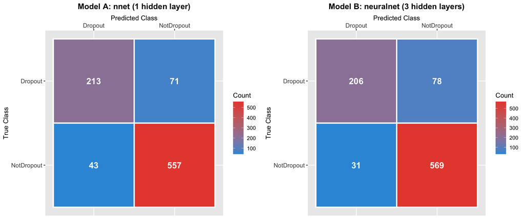

```r
# Helper function to create confusion matrix plot
nn_plot_confusion_matrix <- function(conf_matrix, title) {
  cm_df <- as.data.frame(conf_matrix$table)
  names(cm_df) <- c("Predicted", "True", "Count")

  ggplot(cm_df, aes(x = Predicted, y = True, fill = Count)) +
    geom_tile(color = "white", linewidth = 1) +
    geom_text(aes(label = Count), size = 5, fontface = "bold", color = "white") +
    scale_fill_gradient(low = "#3498DB", high = "#E74C3C", name = "Count") +
    scale_x_discrete(position = "top") +
    scale_y_discrete(limits = rev(c("Dropout", "NotDropout"))) +
    labs(title = title, x = "Predicted Class", y = "True Class") +
    theme(
      plot.title = element_text(hjust = 0.5, face = "bold", size = 13),
      axis.text = element_text(size = 10),
      legend.position = "right"
    )
}

# Create plots for both models
plot_A <- nn_plot_confusion_matrix(conf_matrix_A, "Model A: nnet (1 hidden layer)")
plot_B <- nn_plot_confusion_matrix(conf_matrix_B, "Model B: neuralnet (3 hidden layers)")

# Display side by side
grid.arrange(plot_A, plot_B, ncol = 2)
```

### Performance Metrics Summary

We report accuracy, precision, recall for both NN models. In the binary setting, we treat **Dropout** as the “positive” class (this matches the business goal of flagging students who may need support).

```r
nn_metrics_df <- tibble(
  Model = c("Model A: nnet (1 hidden layer)", "Model B: neuralnet (3 hidden layers)"),
  Accuracy = c(
    as.numeric(conf_matrix_A$overall["Accuracy"]),
    as.numeric(conf_matrix_B$overall["Accuracy"])
  ),
  Precision = c(
    as.numeric(conf_matrix_A$byClass["Pos Pred Value"]),
    as.numeric(conf_matrix_B$byClass["Pos Pred Value"])
  ),
  Recall = c(
    as.numeric(conf_matrix_A$byClass["Sensitivity"]),
    as.numeric(conf_matrix_B$byClass["Sensitivity"])
  )
)
```

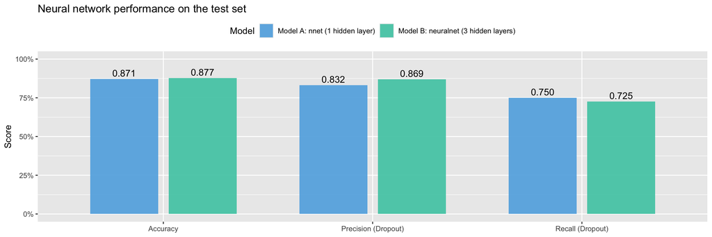

```r
nn_metrics_long <- nn_metrics_df %>%
  pivot_longer(cols = c(Accuracy, Precision, Recall), names_to = "Metric", values_to = "Value") %>%
  mutate(
    Metric = recode(
      Metric,
      Accuracy = "Accuracy",
      Precision = "Precision (Dropout)",
      Recall = "Recall (Dropout)"
    )
  )

ggplot(nn_metrics_long, aes(x = Metric, y = Value, fill = Model)) +
  geom_col(position = position_dodge(width = 0.75), width = 0.65, alpha = 0.9) +
  geom_text(
    aes(label = sprintf("%.3f", Value)),
    position = position_dodge(width = 0.75),
    vjust = -0.4,
    size = 4
  ) +
  scale_y_continuous(limits = c(0, 1), labels = scales::percent_format(accuracy = 1)) +
  scale_fill_manual(values = c("#5DADE2", "#48C9B0")) +
  labs(
    title = "Neural network performance on the test set",
    x = NULL,
    y = "Score",
    fill = "Model"
  ) +
  theme(legend.position = "top")
```

**Interpreting the metrics:**

- **Accuracy(Dropout)** = (TP + TN) / Total — Overall correctness. Model A: 87.1%, Model B: 87.7%
- **Precision (Dropout)** = TP / (TP + FP) — “Of students predicted as Dropout, how many actually dropped out?” Higher precision = fewer false alarms. Model B (86.9%) > Model A (83.2%)
- **Recall (Dropout)** = TP / (TP + FN) — “Of actual dropouts, how many did we catch?” Higher recall = fewer missed at-risk students. Model A (75.0%) > Model B (72.5%)

**Trade-off:** Model B has higher precision (fewer false positives) but lower recall (misses more true dropouts). For an early warning system, **recall matters more** — we’d rather flag some students unnecessarily than miss at-risk ones. Model A’s higher recall makes it slightly better for intervention purposes.

### ROC Curve Comparison

We compare ROC curves for **Dropout** (Dropout vs NotDropout) across both models using `ROCR`.

```r
# --- Model A ROC (nnet) ---
prob_A <- predict(model_A, newdata = test_nn, type = "raw")

# Safety: nnet with binary target outputs P(Class 2), which is NotDropout.
# We need P(Dropout).
if (is.null(dim(prob_A)) || ncol(prob_A) == 1) {
  prob_A_drop <- 1 - as.numeric(prob_A)
} else if ("Dropout" %in% colnames(prob_A)) {
  prob_A_drop <- prob_A[, "Dropout"]
} else {
  prob_A_drop <- prob_A[, 1]
}

pred_A_drop <- ROCR::prediction(prob_A_drop, test_nn$Target == "Dropout")
perf_A_drop <- ROCR::performance(pred_A_drop, "tpr", "fpr")
auc_A <- round(ROCR::performance(pred_A_drop, "auc")@y.values[[1]], 3)

# --- Model B ROC (neuralnet) ---
if (is.null(dim(pred_B_raw))) {
  prob_B_drop <- as.numeric(pred_B_raw)
} else {
  prob_B_drop <- pred_B_raw[, 1]
}
pred_B_drop <- ROCR::prediction(prob_B_drop, test_nn$Target == "Dropout")
perf_B_drop <- ROCR::performance(pred_B_drop, "tpr", "fpr")
auc_B <- round(ROCR::performance(pred_B_drop, "auc")@y.values[[1]], 3)
```

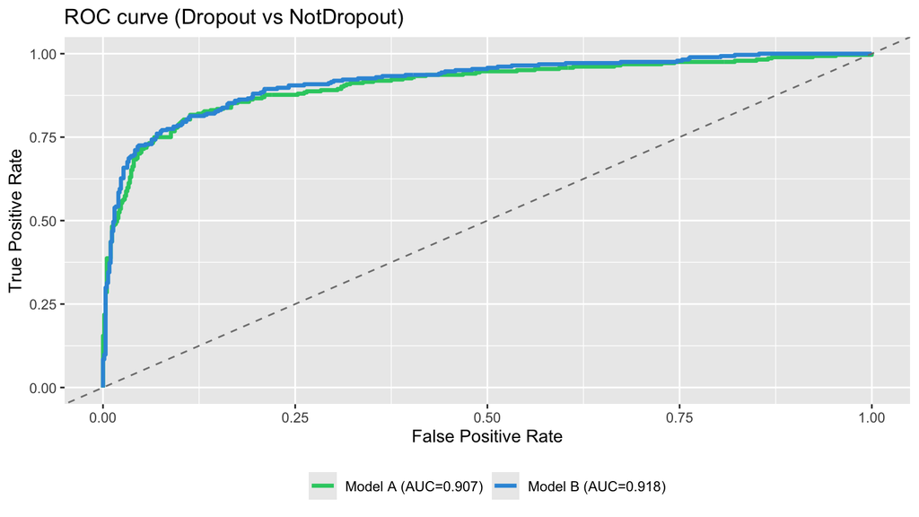

```r
roc_A_df <- data.frame(
  FPR = perf_A_drop@x.values[[1]],
  TPR = perf_A_drop@y.values[[1]],
  Model = sprintf("Model A (AUC=%.3f)", auc_A)
)
roc_B_df <- data.frame(
  FPR = perf_B_drop@x.values[[1]],
  TPR = perf_B_drop@y.values[[1]],
  Model = sprintf("Model B (AUC=%.3f)", auc_B)
)
roc_df <- bind_rows(roc_A_df, roc_B_df)

ggplot(roc_df, aes(x = FPR, y = TPR, color = Model)) +
  geom_line(linewidth = 1.2) +
  geom_abline(slope = 1, intercept = 0, linetype = 2, color = "gray50") +
  scale_color_manual(values = c("#2ecc71", "#3498db")) +
  labs(
    title = "ROC curve (Dropout vs NotDropout)",
    x = "False Positive Rate",
    y = "True Positive Rate",
    color = NULL
  ) +
  theme(legend.position = "bottom")
```

**AUC interpretation:** higher AUC means better separation of Dropout vs NotDropout. Here, Model A has AUC **0.907** and Model B has AUC **0.918**. But **the difference is minimal**.

## 8.7 Feature Importance (Permutation)

**Why we need this:** Unlike GLMs where we can interpret coefficients directly, neural networks are “black boxes” — we can’t use `drop1()` or `anova()` on them. **Permutation importance** is the standard technique to understand which features matter most.

**How it works (simple explanation):** 1. Train the model and record its accuracy (e.g., 87%) 2. Take one feature (e.g., “2nd Sem Grade”) and randomly shuffle its values 3. Measure the new accuracy — if it drops a lot (e.g., 87% → 70%), that feature was important 4. Repeat for each feature

**Interpretation:** A bigger drop in accuracy = the model relied more on that feature. Features with small drops can be shuffled without hurting performance, meaning the model didn’t use them much.

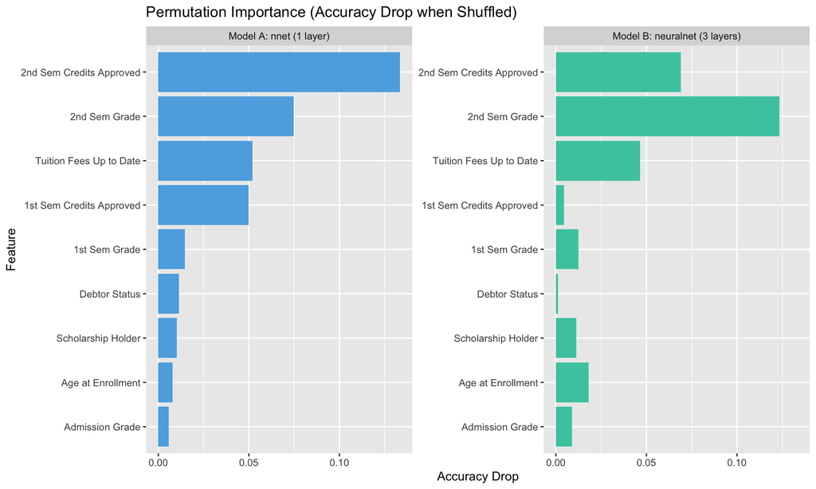

```r
# Helper to compute accuracy drop for a single feature and model
permute_feature <- function(model_type, var_name) {
  permuted <- test_nn
  permuted[[var_name]] <- sample(permuted[[var_name]])

  if (model_type == "Model A: nnet (1 layer)") {
    baseline <- mean(predict(model_A, newdata = test_nn, type = "class") == test_nn$Target)
    perm_acc <- mean(predict(model_A, newdata = permuted, type = "class") == test_nn$Target)
  } else {
    permuted_matrix <- as.data.frame(predict(dummies, newdata = permuted))
    permuted_matrix[] <- lapply(permuted_matrix, as.numeric)
    class_map <- c("Dropout", "NotDropout")
    baseline <- mean(pred_B_class == test_nn$Target)
    perm_raw <- compute(model_B, as.matrix(permuted_matrix[, input_names]))$net.result
    perm_class <- factor(class_map[apply(perm_raw, 1, which.max)], levels = class_map)
    perm_acc <- mean(perm_class == test_nn$Target)
  }

  tibble(
    Model = model_type,
    Feature = var_name,
    AccuracyDrop = baseline - perm_acc
  )
}

perm_results <- map_dfr(
  nn_features,
  ~bind_rows(
    permute_feature("Model A: nnet (1 layer)", .x),
    permute_feature("Model B: neuralnet (3 layers)", .x)
  )
)

# Friendlier labels for the plot
feature_labels <- c(
  "Curricular.units.1st.sem..approved." = "1st Sem Credits Approved",
  "Curricular.units.1st.sem..grade." = "1st Sem Grade",
  "Curricular.units.2nd.sem..approved." = "2nd Sem Credits Approved",
  "Curricular.units.2nd.sem..grade." = "2nd Sem Grade",
  "Tuition.fees.up.to.date" = "Tuition Fees Up to Date",
  "Scholarship.holder" = "Scholarship Holder",
  "Age.at.enrollment" = "Age at Enrollment",
  "Admission.grade" = "Admission Grade",
  "Debtor" = "Debtor Status"
)

perm_results <- perm_results %>%
  mutate(Feature = recode(Feature, !!!feature_labels)) %>%
  group_by(Model) %>%
  mutate(Feature = fct_reorder(Feature, AccuracyDrop)) %>%
  ungroup()

ggplot(perm_results, aes(x = AccuracyDrop, y = Feature, fill = Model)) +
  geom_col(show.legend = FALSE) +
  facet_wrap(~Model, scales = "free_y") +
  labs(
    title = "Permutation Importance (Accuracy Drop when Shuffled)",
    x = "Accuracy Drop",
    y = "Feature"
  ) +
  scale_fill_manual(values = c("#5DADE2", "#48C9B0"))
```

```r
perm_top <- perm_results %>%
  group_by(Model) %>%
  slice_max(order_by = AccuracyDrop, n = 5, with_ties = FALSE) %>%
  ungroup() %>%
  mutate(AccuracyDropPctPoints = round(AccuracyDrop * 100, 2)) %>%
  select(Model, Feature, AccuracyDropPctPoints)

knitr::kable(
  perm_top,
  caption = "Top 5 permutation importances (how many accuracy percentage points we lose when we shuffle the feature)"
)
```

Top 5 permutation importances (how many accuracy percentage points we lose when we shuffle the feature)

| Model | Feature | AccuracyDropPctPoints |
| --- | --- | --- |
| Model A: nnet (1 layer) | 2nd Sem Credits Approved | 13.35 |
| Model A: nnet (1 layer) | 2nd Sem Grade | 7.47 |
| Model A: nnet (1 layer) | Tuition Fees Up to Date | 5.20 |
| Model A: nnet (1 layer) | 1st Sem Credits Approved | 4.98 |
| Model A: nnet (1 layer) | 1st Sem Grade | 1.47 |
| Model B: neuralnet (3 layers) | 2nd Sem Grade | 12.33 |
| Model B: neuralnet (3 layers) | 2nd Sem Credits Approved | 6.90 |
| Model B: neuralnet (3 layers) | Tuition Fees Up to Date | 4.64 |
| Model B: neuralnet (3 layers) | Age at Enrollment | 1.81 |
| Model B: neuralnet (3 layers) | 1st Sem Grade | 1.24 |

## 8.8 Business Use: Early Warning and Intervention

This neural network can be used as an **early warning system**:

1. At the end of the 1st/2nd semester, we collect the same inputs (grades, approved units, tuition status, scholarship, debtor status).
2. The model outputs a **dropout risk score** for each student (the model’s predicted output/probability for the **Dropout** class).
3. The university can then **target limited support resources** to students with the highest predicted risk.

Examples of interventions (linked to our most important features):

- **Academic performance signals (grades, approved units):** provide tutoring, mentoring, and early academic advising.
- **Financial stress signals (tuition up to date, debtor):** proactive outreach about payment plans and financial aid options.
- **Support signals (scholarship holder):** consider expanding support programs for similar students who are not currently covered.

Important caution:

- The model helps us **prioritize** students for support, but it should not be the only decision tool.
- The safest process is to combine model predictions with human review (advisors) before taking action.

## 8.9 Neural Network Architecture Visualization

`NeuralNetTools::plotnet()` turns the fitted networks into diagrams that show layers, neurons, and connection strengths (thicker lines = larger absolute weights).

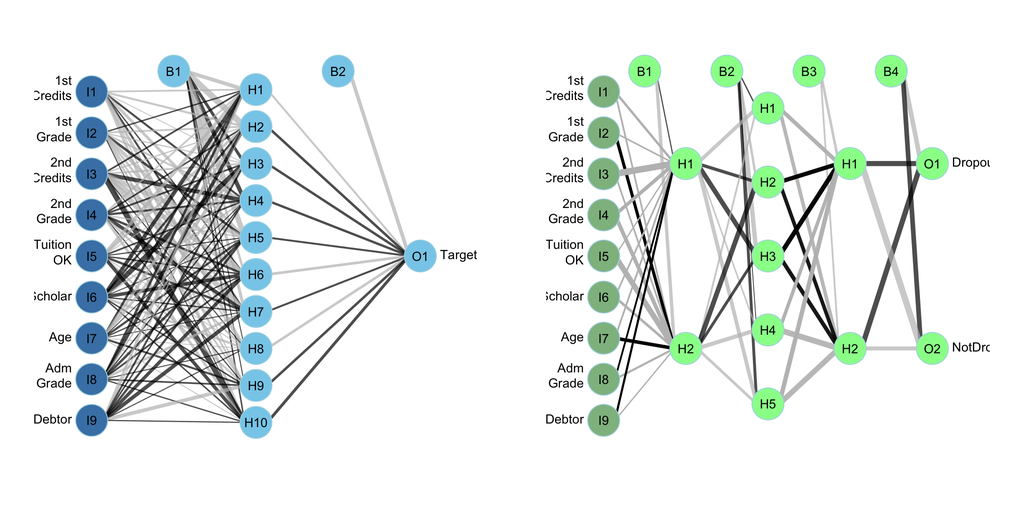

```r
short_labels <- c("1st\nCredits", "1st\nGrade", "2nd\nCredits", "2nd\nGrade",
                  "Tuition\nOK", "Scholar", "Age", "Adm\nGrade", "Debtor")
output_labels_B <- c("Dropout", "NotDropout")

par(mfrow = c(1, 2), mar = c(2, 2, 2, 2))
NeuralNetTools::plotnet(
  model_A,
  alpha = 0.7,
  circle_col = list("steelblue", "skyblue"),
  x_names = short_labels,
  max_sp = TRUE,
  cex_val = 0.9,
  line_lwd = 0.8
)
NeuralNetTools::plotnet(
  model_B,
  alpha = 0.7,
  circle_col = list("darkseagreen", "palegreen"),
  x_names = short_labels,
  y_names = output_labels_B,
  max_sp = TRUE,
  cex_val = 0.9,
  line_lwd = 0.8
)
```

```r
par(mfrow = c(1, 1))
```

## 8.10 Neural Network Conclusions

**Model A (nnet):** 9 inputs - 10 hidden neurons - 1 output (P(NotDropout)). **Model B (neuralnet):** 9 inputs - 2 - 5 - 2 neurons - 2 outputs.

**Limitations observed:**

- Deeper networks remain **sensitive to hyperparameters** and can overfit small samples.
- **Interpretability** is **limited** compared to GLM/GAM coefficients.
- Because we combine **Enrolled + Graduate** into **NotDropout**, this target cannot distinguish “still studying” from “already graduated”. This is acceptable for an early-warning dropout use case, but it matters if the business question is specifically “who will graduate”.

# 9. Support Vector Machine Analysis

**Business Question:** *“Who is classified as at risk of dropping out?”* (from Section 1.1)

Support Vector Machines represent our **robust, high-accuracy classifier** for the Early Warning System. They find the **maximum margin** boundary that best separates dropout students from successful ones. We test three kernel types (Linear, Radial, Polynomial) to determine which decision boundary works best.

```r
# Load the dataset from the project data folder
student_data <- read_csv("data/preprocessed_data.csv")

# Create binary target: Dropout vs Not Dropout (Graduate + Enrolled)
# This aligns with the Early Warning System goal and is consistent with our Neural Network
student_data <- student_data %>%
  mutate(Target = ifelse(Target == "Dropout", "Dropout", "Not Dropout"))

# Convert Target to factor
student_data$Target <- factor(student_data$Target, levels = c("Dropout", "Not Dropout"))
```

We will now test different **SVM kernels** to understand which is the best classifier for our student performance prediction. SVMs operate by identifying where the **margin** between different categories of data is the greatest. To classify our dataset, the model plots a separating line between the two outcome classes using a number of predictors - in order to keep it clear, we want to create a two-dimensional plane (two predictors).

By applying different kernels—linear, radial, and polynomial— we assess how the shape of the decision boundary affects prediction accuracy and determine which kernel provides the most reliable classification for our dataset.

## 9.1 Feature Selection

For us to choose the best predictors, we will compute **F-statistic ANOVA** for every numeric feature in the dataset. The F-score tells us *how much* the **mean** of each feature **differs** between the **two target groups** (*Dropout* vs *Not Dropout*). Higher scores mean bigger separation between classes, making the feature more useful for classification.

To visualize the SVM decision boundary, we need to limit our analysis to **two features** (creating a 2D plot with X and Y axes). We selected **second semester marks** and **courses approved** as they have the highest F-values, indicating they best separate Dropout from Not Dropout students.

```r
numeric_cols <- sapply(student_data, is.numeric)
features <- names(student_data)[numeric_cols]
# Remove Target if it's numeric
features <- features[features != "Target"]

results <- data.frame(
  Feature = character(),
  F_value = numeric(),
  p_value = numeric(),
  stringsAsFactors = FALSE
)

for (feat in features) {
  formula <- as.formula(paste(feat, "~ Target"))
  anova_result <- aov(formula, data = student_data)
  summary_anova <- summary(anova_result)

  results <- rbind(
    results,
    data.frame(
      Feature = feat,
      F_value = round(summary_anova[[1]]$`F value`[1], 2),
      p_value = sprintf("%.3f", summary_anova[[1]]$`Pr(>F)`[1])
    )
  )
}

results <- results[order(-results$F_value), ]
rownames(results) <- NULL
knitr::kable(head(results, 5), caption = "Top 5 Features by F-statistic")
```

Top 5 Features by F-statistic

| Feature | F_value | p_value |
| --- | --- | --- |
| Curricular.units.2nd.sem..grade. | 2148.06 | 0.000 |
| Curricular.units.2nd.sem..approved. | 2122.62 | 0.000 |
| Curricular.units.1st.sem..grade. | 1328.64 | 0.000 |
| Curricular.units.1st.sem..approved. | 1317.49 | 0.000 |
| Tuition.fees.up.to.date | 998.24 | 0.000 |

## 9.2 Data Preparation & Train/Test Split

For consistency with our Neural Network model and the Early Warning System goal, we use a **binary classification**: *Dropout* vs *Not Dropout* (which includes both Graduate and Enrolled students). This approach makes sense because at prediction time, all students are enrolled — we want to predict if they will drop out.

```r
# Get the top 2 features (excluding Target)
top_feature_1 <- as.character(results$Feature[1])
top_feature_2 <- as.character(results$Feature[2])

# Create marks dataframe with selected features
marks <- data.frame(
  x.1 = student_data[[top_feature_1]],
  x.2 = student_data[[top_feature_2]],
  y = as.factor(student_data$Target)
)

# Remove rows with NA values if any exist
marks <- na.omit(marks)
```

```r
# Create summary table
data_summary <- data.frame(
  Metric = c("Total Observations", "Target Classes"),
  Value = c(nrow(marks), paste(levels(marks$y), collapse=", "))
)

knitr::kable(data_summary, align = 'c', caption = "Dataset Summary")
```

Dataset Summary

| Metric | Value |
| --- | --- |
| Total Observations | 4424 |
| Target Classes | Dropout, Not Dropout |

We split the data 80/20 for training and testing:

```r
# svm-train-test-split
set.seed(123)
trainIndex <- createDataPartition(marks$y, p = 0.8, list = FALSE)
train_data <- marks[trainIndex, ]
test_data <- marks[-trainIndex, ]
# Create split summary table
split_summary <- data.frame(
  Dataset = c("Training", "Testing"),
  Observations = c(nrow(train_data), nrow(test_data)),
  Percentage = c(
    paste0(round(nrow(train_data)/nrow(marks)*100, 1), "%"),
    paste0(round(nrow(test_data)/nrow(marks)*100, 1), "%")
  )
)

knitr::kable(split_summary, align = 'c', caption = "Train/Test Split")
```

Train/Test Split

| Dataset | Observations | Percentage |
| --- | --- | --- |
| Training | 3540 | 80% |
| Testing | 884 | 20% |

## 9.3 Model Training & Tuning

We train and optimize **all three SVM kernels** using `tune()` to find the best hyperparameters for each. This ensures a fair comparison rather than using arbitrary parameter values.

**Linear Kernel**: Creates a straight decision boundary to separate classes. This kernel is ideal when the data is linearly separable.  
**Radial Basis Function (RBF) Kernel**: Generates curved, non-linear decision boundaries by measuring the distance between data points.  
**Polynomial Kernel**: Produces curved boundaries with a specific degree of curve.

```r
set.seed(123)

# 1. Linear Kernel (Tune cost only)
tune_linear <- tune(svm, y ~ x.1 + x.2, data = train_data,
                    kernel = "linear",
                    ranges = list(cost = c(0.1, 1, 10, 100)))
svm_linear <- tune_linear$best.model

# 2. Radial Kernel (Tune cost + gamma)
tune_radial <- tune(svm, y ~ x.1 + x.2, data = train_data,
                    kernel = "radial",
                    ranges = list(cost = c(0.1, 1, 10, 100),
                                 gamma = c(0.1, 0.5, 1, 2)))
svm_radial <- tune_radial$best.model

# 3. Polynomial Kernel (Tune cost + degree)
tune_poly <- tune(svm, y ~ x.1 + x.2, data = train_data,
                  kernel = "polynomial",
                  ranges = list(cost = c(0.1, 1, 10),
                               degree = c(2, 3, 4)))
svm_poly <- tune_poly$best.model
```

**Optimal Hyperparameters:**

## 9.4 Decision Boundary Comparison

The plots below compare the **“Rigid” Linear Boundary** against the **“Flexible” Tuned Radial Boundary**. The decision boundary represents the “Safe Zone” — students above the line are predicted to *Not Dropout*, while those below are flagged as *Dropout* risk.

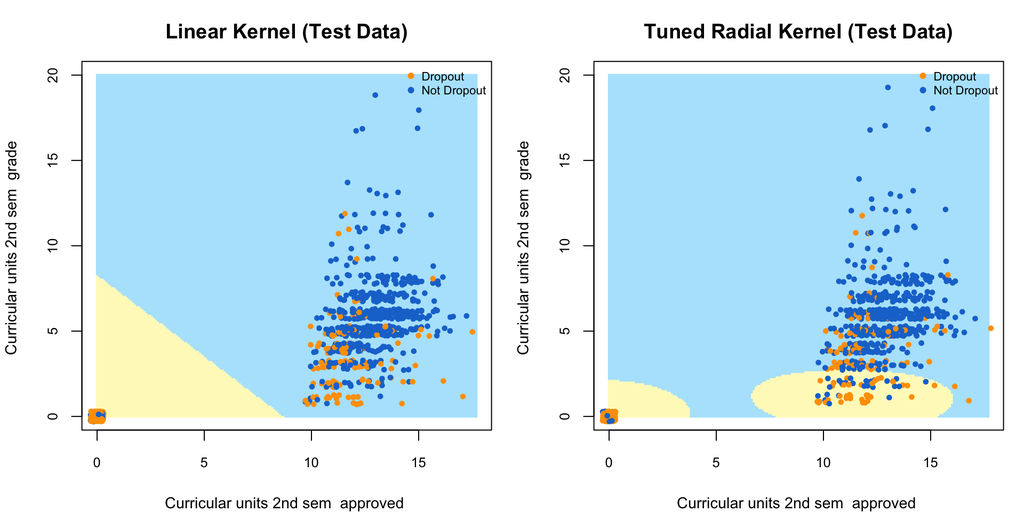

The **Linear kernel** creates a simple straight line cut-off. The **Radial kernel** is more sophisticated: notice how it creates a second “risk zone” (yellow blob) for students with many approved units but very low grades. The Linear model misses these at-risk students, classifying them as safe.

## 9.5 Visual Comparison: Confusion Matrices

Here we visually compare where the models make mistakes. The **Linear Model** serves as our baseline.

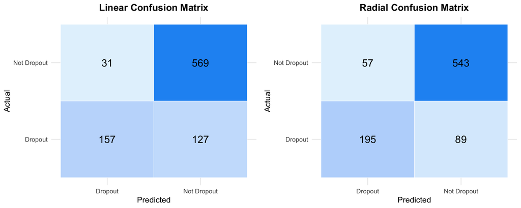

**Interpretation:** The confusion matrices show where each model makes errors. For an Early Warning System, **false negatives** (predicting “Not Dropout” for students who actually dropout) are more costly than false positives.

Comparing the two models:

- **Linear kernel:** Catches 157 dropouts, but **misses 127** (false negatives)
- **Radial kernel:** Catches 195 dropouts, but **misses only 89** (false negatives)

The Radial kernel reduces missed dropout cases by **30%** (from 127 to 89). The trade-off is 26 extra false alarms (57 vs 31), which is acceptable since extra support for non-at-risk students causes no harm.

## 9.6 Performance Summary

All three kernels were optimized using grid search to find the best hyperparameters. The table below compares their final performance on the test set:

```r
# Calculate predictions for all models
pred_lin <- predict(svm_linear, test_data)
pred_rad <- predict(svm_radial, test_data)
pred_poly <- predict(svm_poly, test_data)

cm_linear <- confusionMatrix(pred_lin, test_data$y)
cm_radial <- confusionMatrix(pred_rad, test_data$y)
cm_poly   <- confusionMatrix(pred_poly, test_data$y)

comparison_results <- data.frame(
  Model = c("Linear", "Radial", "Polynomial"),
  Accuracy = c(cm_linear$overall['Accuracy'],
               cm_radial$overall['Accuracy'],
               cm_poly$overall['Accuracy']),
  Sensitivity = c(cm_linear$byClass['Sensitivity'],
                  cm_radial$byClass['Sensitivity'],
                  cm_poly$byClass['Sensitivity']),
  Kappa = c(cm_linear$overall['Kappa'],
            cm_radial$overall['Kappa'],
            cm_poly$overall['Kappa'])
)

# Store best model info using numeric values
svm_best_idx <- which.max(comparison_results$Accuracy)
svm_best_model <- comparison_results$Model[svm_best_idx]
svm_best_accuracy <- comparison_results$Accuracy[svm_best_idx]

# Create display table with formatting
display_table <- comparison_results
display_table[,2:3] <- lapply(display_table[,2:3], function(x) sprintf("%.1f%%", x*100))
display_table$Kappa <- round(display_table$Kappa, 3)

knitr::kable(display_table, caption = "Model Accuracy Comparison", align = 'c')
```

Model Accuracy Comparison

| Model | Accuracy | Sensitivity | Kappa |
| --- | --- | --- | --- |
| Linear | 82.1% | 55.3% | 0.55 |
| Radial | 83.5% | 68.7% | 0.61 |
| Polynomial | 82.1% | 55.3% | 0.55 |

Based on these results, the **Radial kernel** performs best with the highest accuracy and sensitivity. This makes it the recommended choice for the Early Warning System to identify at-risk students.

## Cross Validation will be elaborated in next Chapter 10.

# 10. Model Comparison & Cross Validation

## 10.1 Model Overview

Each model in our analysis serves a specific purpose in our client’s decision-making toolkit:

This models gives our client flexibility: interpretable models for policy discussions, high-accuracy models for daily operations.

[output not shown]

### Early Warning System Approaches

**Two prediction timelines are possible with our models:**

[interactive chart not shown]

## 10.2 Cross Validation

Given the promising performance of the Support Vector Machines in Chapter 9, we proceed with a rigorous confirmation step. We use **10-Fold Cross-Validation** to test the stability of the three kernels.

For a fair comparison, all models use the exact same configuration as the previous section: - **Target:** Dropout vs Not Dropout - **Predictors:** 2nd Sem Grade, 2nd Sem Approved - **Data:** Full dataset (binary classification)

> **Note on Methodology:** To efficiently verify the stability of our *optimized* models, we use the fixed hyperparameters identified in Chapter 9 (via `tune()`) rather than re-tuning inside each fold. This validates that our chosen model configurations perform reliably across different data subsets.

```r
# 10-Fold Cross-Validation for SVM Kernels
set.seed(42)

# Use the 'marks' dataset from Chapter 9 (Dropout vs Not Dropout)
data_cv <- marks
n <- nrow(data_cv)

# Parameters
K <- 10
folds <- sample(rep(1:K, length.out = n))

# Storage for accuracy results
acc_linear <- numeric(K)
acc_radial <- numeric(K)
acc_poly <- numeric(K)

# Loop through k folds
for(k in 1:K) {
    # Split into train/test for this fold
    test_idx <- which(folds == k)
    train_fold <- data_cv[-test_idx, ]
    test_fold <- data_cv[test_idx, ]

    # Train using the TUNED parameters found in Chapter 9
    # We access 'best.parameters' from the tune objects to ensure we use the optimized values
    m_lin <- svm(y ~ x.1 + x.2, data = train_fold, kernel = "linear",
                 cost = tune_linear$best.parameters$cost)

    m_rad <- svm(y ~ x.1 + x.2, data = train_fold, kernel = "radial",
                 cost = tune_radial$best.parameters$cost,
                 gamma = tune_radial$best.parameters$gamma)

    m_pol <- svm(y ~ x.1 + x.2, data = train_fold, kernel = "polynomial",
                 cost = tune_poly$best.parameters$cost,
                 degree = tune_poly$best.parameters$degree)

    # Predict & Calculate Accuracy
    p_lin <- predict(m_lin, test_fold)
    p_rad <- predict(m_rad, test_fold)
    p_pol <- predict(m_pol, test_fold)

    acc_linear[k] <- mean(p_lin == test_fold$y)
    acc_radial[k] <- mean(p_rad == test_fold$y)
    acc_poly[k]   <- mean(p_pol == test_fold$y)
}
```

### Cross-Validation Results

The boxplot below shows the spread of accuracy scores across the 10 folds. A narrower box indicates a more **stable** model.

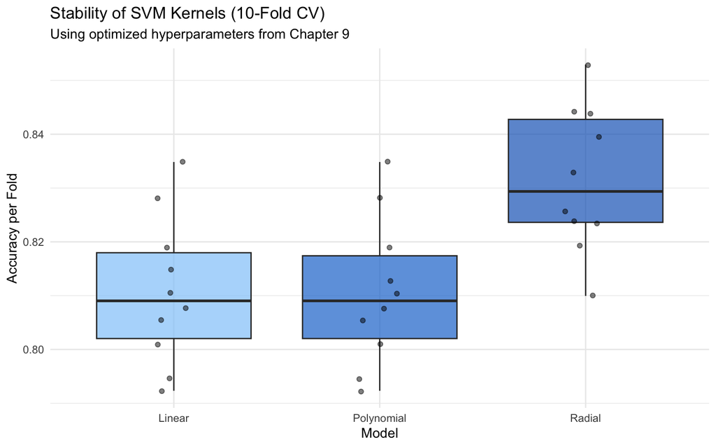

```r
# Combine results for plotting
cv_results <- data.frame(
  Accuracy = c(acc_linear, acc_radial, acc_poly),
  Model = factor(rep(c("Linear", "Radial", "Polynomial"), each = K))
)

# Visual comparison of stability
print(ggplot(cv_results, aes(x = Model, y = Accuracy, fill = Model)) +
  geom_boxplot(alpha = 0.7) +
  geom_jitter(width = 0.1, alpha = 0.5) +  # Show individual fold scores
  labs(title = "Stability of SVM Kernels (10-Fold CV)",
       subtitle = "Using optimized hyperparameters from Chapter 9",
       y = "Accuracy per Fold") +
  theme_minimal() +
  scale_fill_manual(values = c("#90CAF9", "#1976D2", "#1565C0")) +
  theme(legend.position = "none"))
```

```r
# Summary table
cv_summary <- cv_results %>%
  group_by(Model) %>%
  summarise(
    Mean_Accuracy = sprintf("%.1f%%", mean(Accuracy)*100),
    SD = sprintf("%.3f", sd(Accuracy)),
    Min = sprintf("%.1f%%", min(Accuracy)*100),
    Max = sprintf("%.1f%%", max(Accuracy)*100)
  )

knitr::kable(cv_summary, caption = "10-Fold CV Performance Statistics", align = 'c')
```

10-Fold CV Performance Statistics

| Model | Mean_Accuracy | SD | Min | Max |
| --- | --- | --- | --- | --- |
| Linear | 81.1% | 0.014 | 79.2% | 83.5% |
| Polynomial | 81.1% | 0.014 | 79.2% | 83.5% |
| Radial | 83.2% | 0.013 | 81.0% | 85.3% |

### Statistical Comparison

To confirm if the differences are statistically significant, we perform paired t-tests between the kernels.

```r
# Paired t-tests to compare kernels
t_lin_vs_rad <- t.test(acc_linear, acc_radial, paired = TRUE)
t_lin_vs_poly <- t.test(acc_linear, acc_poly, paired = TRUE)
t_rad_vs_poly <- t.test(acc_radial, acc_poly, paired = TRUE)

# Results table
stat_results <- data.frame(
  Comparison = c("Linear vs Radial", "Linear vs Poly", "Radial vs Poly"),
  p_value = c(t_lin_vs_rad$p.value, t_lin_vs_poly$p.value, t_rad_vs_poly$p.value)
)
stat_results$Significant <- stat_results$p_value < 0.05

knitr::kable(stat_results,
             caption = "Paired t-test Results (α = 0.05)",
             digits = 4,
             align = 'c')
```

Paired t-test Results (α = 0.05)

| Comparison | p_value | Significant |
| --- | --- | --- |
| Linear vs Radial | 0.0000 | TRUE |
| Linear vs Poly | 0.3434 | FALSE |
| Radial vs Poly | 0.0000 | TRUE |

### CV Conclusion

- **Radial kernel** achieves a mean accuracy of 83.2%.
- **Linear kernel** achieves 81.1%.
- **Polynomial kernel** achieves 81.1%.

This confirms the findings from Section 9: The **Radial Kernel** is the most robust and accurate model for our Early Warning System. Its ability to capture non-linear relationships gives it a crucial edge in correctly identifying at-risk students.

# 11. Conclusions & Business Recommendations

## 11.1 Key Findings

We identified **second semester academic performance** as the **strongest predictors** of student success or dropout, this was proven in our most reliable models SVM and NN features selection process. However, for the business case, first semester **early warning** could make more sense, as first semester performance comes as second often as the most important features.

## 11.2 Business Recommendations

Our models suggest that **grade performance** and **financial stability** are the most critical factors for student retention. We propose the following structured intervention strategy:

**1. For Our Client University (Two-Stage Filter):**

- **Implement “Option 2” EarlyWarning System:**
- **Stage 1 (After Sem 1):** Deploy the **Binomial GLM** or **1st-Sem SVM** as a broad screening tool. The goal is *prevention*, flag students with difficulty early.
- **Stage 2 (After Sem 2):** Deploy the higher precision **Neural Network** or **SVM** . The goal is *crisis intervention*. Accurately identify students who are on the brink of dropout for intensive counseling.
- **Human-in-the-Loop Protocol:** Use the model as a *filtering tool*. High-risk lists should be reviewed by advisors, not used for automated decisions.

**2. For Academic Advisors:**  
* **Early Warning is key:** Do not wait for the 2nd semester. If the **system predicts dropout** based on first-semester data (where failing multiple courses is a key driver), this is the single biggest red flag for action. And another drop-out signal in 2nd semester would be definitive signal for immediate intervention.  
* **Multi-faceted Support:** Combine academic tutoring with financial counseling, as financial stress (debtor status) is a key dropout factor too.

**3. For Policy Makers:**  
* **Economic Context:** External factors like Unemployment Rate and GDP have minor effects on academic success (The Linear Regression coefficients (Section 4.8) show GDP/Unemployment have small effect sizes). This could be considered into policy making as background information.  
* **Financial Safety Nets:** Consider policy to provide scholarship and emergency loan programs for in-risk students.

# 12. Limitations & Future Work

## 12.1 Limitations

Our dataset focuses on academic records and financial indicators, but real student life is more complex. We don’t have data on **motivation**, **mental health**, or **study habits** (like how often someone visits the library or attends tutoring). These “soft” factors likely matter a lot, but they’re hard to collect.

Finally, this is a Portuguese institution with its own grading scale (0-20). What works here might not directly transfer to HSLU or other universities without recalibration. A standardized scoring system would be needed for broader use.

## 12.2 Ideas for Future Work

1. **Behavioral Signals:** Library check-ins, Ilias login frequency, and assignment submission times could significantly boost predictive power.
2. **Cross-University Validation:** Scaling this system to other universities (e.g., HSLU) to test robustness across different institutions.

# 13. References

1. OECD (2025). *Education at a Glance 2025*. OECD. https://www.oecd.org/en/publications/education-at-a-glance-2025_1a3543e2-en/switzerland_e7c7fc03-en.html
2. Realinho, V., Machado, J., Baptista, L., & Martins, M.V. (2022). *Predict Students’ Dropout and Academic Success*. UCI Machine Learning Repository. https://doi.org/10.24432/C5MC89

# 14. Generative AI Declaration & Guidelines

Generative AI was used as a supplementary tool on top of the assisting material provided in the Machine Learning1 lecture.

## Guidelines for Responsible and Effective Usage of Gen-AI

1. **Human-in-the-loop verification:** All AI-suggested content was treated as a draft. Text, code, or sources delivered by AI had to be critically reviewed and tested before inclusion.
2. **Emphasis on learning:** Gen-AI functioned as a learning companion rather than an automated code generator. After receiving suggestions, team members engaged in follow-up questions to grasp the underlying logic and method.
3. **Transparency:** The team openly acknowledged where and how AI was used in the workflow so the benefits and quality safeguards remained clear.

## Use Cases of AI Tools in the Machine Learning 1 Course Context

AI-based assistants were applied in the following specific cases:

1. **Brainstorming:** Elaborating initial ideas, structuring thoughts, and outlining coding approaches.
2. **Debugging & optimization:** Explaining error messages and helping improve self-developed scripts to raise efficiency.
3. **Proofreading:** Accelerating grammar and typo checks during documentation.
4. **Information acquisition:** Searching for methodological references or code documentation for R Markdown, or machine learning methods (always followed by human verification of credibility).

## Benefits and Challenges in Using Generative AI Tools

1. **Benefits:** Faster debugging (e.g., resolving R Markdown knitting errors or debugging issues), on-demand tutoring for advanced questions, and more time spent on analytical reasoning instead of routine fixes.
2. **Challenges:** The ease of getting answers can create a temptation to trust outputs blindly. The “human-in-the-loop” guideline ensured the team retained ownership, validating every AI-assisted contribution.